# covid_19

Sharon Lee

5/12/2020

## R Markdown file for Covid-19 in China project

Utilizing the Johns Hopkins and ACAPs dataset to predict confirmed cases in China. From the Johns Hopkins dataset, I will be including the following variables- confirmed, deaths, recovered cases in time series. From the acaps dataset, I will be including the following variables- country, category, measure type, targeted pop group and date implemented. I will be combining those variables listed together into a dataframe for machine learning modeling.

EDA: 1. Johns Hopkins Dataset #read in time series confirmed global data

```r
setwd('C:/USFMSHI/HS630/hw/assign6/COVID-19/csse_covid_19_data/csse_covid_19_time_series/')
time_series <- read.csv("time_series_covid19_confirmed_global.csv", header = T)
```

#extract out china data

```r
time_china <- time_series[which(time_series$Country.Region == "China"), ]
#time_china
```

#take out country, lat and long

```r
time_china <- time_china[, c(-2, -3, -4)]
time_china <- time_china[,-1]
#time_china
```

#first day: 1/22

```r
days <- c(1:97)
colnames(time_china) <- days

#sum up to get accumulated cases of confirmed
China_confirmed <- c()
for(i in colnames(time_china)){
  #print(sum(time_china[,i]))
  China_confirmed[i] <- sum(time_china[,i])
}
China_confirmed
```

```
##     1     2     3     4     5     6     7     8     9    10    11    12    13
##   548   643   920  1406  2075  2877  5509  6087  8141  9802 11891 16630 19716
##    14    15    16    17    18    19    20    21    22    23    24    25    26
## 23707 27440 30587 34110 36814 39829 42354 44386 44759 59895 66358 68413 70513
##    27    28    29    30    31    32    33    34    35    36    37    38    39
## 72434 74211 74619 75077 75550 77001 77022 77241 77754 78166 78600 78928 79356
##    40    41    42    43    44    45    46    47    48    49    50    51    52
## 79932 80136 80261 80386 80537 80690 80770 80823 80860 80887 80921 80932 80945
##    53    54    55    56    57    58    59    60    61    62    63    64    65
## 80977 81003 81033 81058 81102 81156 81250 81305 81435 81498 81591 81661 81782
##    66    67    68    69    70    71    72    73    74    75    76    77    78
## 81897 81999 82122 82198 82279 82361 82432 82511 82543 82602 82665 82718 82809
##    79    80    81    82    83    84    85    86    87    88    89    90    91
## 82883 82941 83014 83134 83213 83306 83356 83403 83760 83787 83805 83817 83853
##    92    93    94    95    96    97
## 83868 83884 83899 83909 83912 83918
```

#creating final dataframe- China

```r
China <- as.data.frame(China_confirmed)
colnames(China) <- "Confirmed"
China
```

```
##    Confirmed
## 1        548
## 2        643
## 3        920
## 4       1406
## 5       2075
## 6       2877
## 7       5509
## 8       6087
## 9       8141
## 10      9802
## 11     11891
## 12     16630
## 13     19716
## 14     23707
```

[output cut: 83 more lines]

#read in time series death global data

```r
setwd('C:/USFMSHI/HS630/hw/assign6/COVID-19/csse_covid_19_data/csse_covid_19_time_series/')
time_series2 <- read.csv("time_series_covid19_deaths_global.csv", header = T)
#time_series2
```

#extract out china data

```r
time_china2 <- time_series2[which(time_series2$Country.Region == "China"), ]
#take out country, lat and long
time_china2 <- time_china2[, c(-2, -3, -4)]
time_china2 <- time_china2[,-1]
#time_china2
```

#get accumulated death cases of china

```r
colnames(time_china2) <- days
China_deaths <- c()
for(i in colnames(time_china2)){
  #print(sum(time_china[,i]))
  China_deaths[i] <- sum(time_china2[,i])
}

China_deaths
```

```
##    1    2    3    4    5    6    7    8    9   10   11   12   13   14   15   16
##   17   18   26   42   56   82  131  133  171  213  259  361  425  491  563  633
##   17   18   19   20   21   22   23   24   25   26   27   28   29   30   31   32
##  718  805  905 1012 1112 1117 1369 1521 1663 1766 1864 2003 2116 2238 2238 2443
##   33   34   35   36   37   38   39   40   41   42   43   44   45   46   47   48
## 2445 2595 2665 2717 2746 2790 2837 2872 2914 2947 2983 3015 3044 3072 3100 3123
##   49   50   51   52   53   54   55   56   57   58   59   60   61   62   63   64
## 3139 3161 3172 3180 3193 3203 3217 3230 3241 3249 3253 3259 3274 3274 3281 3285
##   65   66   67   68   69   70   71   72   73   74   75   76   77   78   79   80
## 3291 3296 3299 3304 3308 3309 3316 3322 3326 3330 3333 3335 3335 3337 3339 3340
##   81   82   83   84   85   86   87   88   89   90   91   92   93   94   95   96
## 3343 3343 3345 3345 3346 3346 4636 4636 4636 4636 4636 4636 4636 4636 4636 4637
##   97
## 4637
```

#add to China dataframe

```r
China$Deaths <- China_deaths
China
```

```
##    Confirmed Deaths
## 1        548     17
## 2        643     18
## 3        920     26
## 4       1406     42
## 5       2075     56
## 6       2877     82
## 7       5509    131
## 8       6087    133
## 9       8141    171
## 10      9802    213
## 11     11891    259
## 12     16630    361
## 13     19716    425
## 14     23707    491
```

[output cut: 83 more lines]

#read in time series recovered global data

```r
setwd('C:/USFMSHI/HS630/hw/assign6/COVID-19/csse_covid_19_data/csse_covid_19_time_series/')
time_series3 <- read.csv("time_series_covid19_recovered_global.csv", header = T)
#time_series3
```

#extract out china data

```r
time_china3 <- time_series3[which(time_series2$Country.Region == "China"), ]
#take out country, lat and long
time_china3 <- time_china3[, c(-2, -3, -4)]
time_china3 <- time_china3[,-1]

colnames(time_china3) <- days
China_recovered <- c()
for(i in colnames(time_china3)){
  China_recovered[i] <- sum(time_china3[,i])
}

China_recovered
```

```
##     1     2     3     4     5     6     7     8     9    10    11    12    13
##    28    28    33    35    45    52    91   105   114   189   239   414   541
##    14    15    16    17    18    19    20    21    22    23    24    25    26
##   737   960  1271  1738  2278  2823  3444  4053  4361  5363  6981  8141  9437
##    27    28    29    30    31    32    33    34    35    36    37    38    39
## 11002 12535 14108 16002 16497 20333 20709 22426 24914 27201 29896 33174 36009
##    40    41    42    43    44    45    46    47    48    49    50    51    52
## 38784 41340 43828 46284 48492 50117 51661 53472 54848 56191 57910 59134 60408
##    53    54    55    56    57    58    59    60    61    62    63    64    65
## 61855 63200 64078 64960 65900 66674 67383 67953 68454 68903 69360 70130 70544
##    66    67    68    69    70    71    72    73    74    75    76    77    78
## 71112 71492 71978 72344 72641 72860 73067 73263 73500 73775 73889 74048 74236
##    79    80    81    82    83    84    85    86    87    88    89    90    91
## 74426 74598 74824 75047 75226 75484 75768 76070 75449 75610 75910 76160 76351
##    92    93    94    95    96    97
## 76613 76868 77293 77565 77938 78237
```

```r
China$Recovered <- China_recovered
China
```

```
##    Confirmed Deaths Recovered
## 1        548     17        28
## 2        643     18        28
## 3        920     26        33
## 4       1406     42        35
## 5       2075     56        45
## 6       2877     82        52
## 7       5509    131        91
## 8       6087    133       105
## 9       8141    171       114
## 10      9802    213       189
## 11     11891    259       239
## 12     16630    361       414
## 13     19716    425       541
## 14     23707    491       737
```

[output cut: 83 more lines]

#create columns that hold confirmed, death and recovered cases for each day instead of accumulation

```r
#confirmed
day_confirmed <- c()
for(i in (2:length(China$Confirmed))){

  day_confirmed[i] <- China$Confirmed[i]- China$Confirmed[i-1]
}
day_confirmed[1] <- China$Confirmed[1]
China$day_confirmed <- day_confirmed

#death
day_death <- c()
for(i in (2:length(China$Deaths))){

  day_death[i] <- China$Deaths[i]- China$Deaths[i-1]
}
day_death[1] <- China$Deaths[1]
China$day_death <- day_death

#recovered
day_rec <- c()
for(i in (2:length(China$Recovered))){

  day_rec[i] <- China$Recovered[i]- China$Recovered[i-1]
}
day_rec[1] <- China$Recovered[1]
China$day_recovered <- day_rec
China
```

```
##    Confirmed Deaths Recovered day_confirmed day_death day_recovered
## 1        548     17        28           548        17            28
## 2        643     18        28            95         1             0
## 3        920     26        33           277         8             5
## 4       1406     42        35           486        16             2
## 5       2075     56        45           669        14            10
## 6       2877     82        52           802        26             7
## 7       5509    131        91          2632        49            39
## 8       6087    133       105           578         2            14
## 9       8141    171       114          2054        38             9
## 10      9802    213       189          1661        42            75
## 11     11891    259       239          2089        46            50
## 12     16630    361       414          4739       102           175
## 13     19716    425       541          3086        64           127
## 14     23707    491       737          3991        66           196
```

[output cut: 83 more lines]

#add day column

```r
startDate <- as.Date("2020-01-22")
endDate <- as.Date("2020-04-27")
date <- seq(startDate, endDate, "1 day")
China$day <- date
```

2. ACAPS Dataset

```r
setwd('C:/USFMSHI/HS630/hw/assign6/other_datasets')
safety <- read.csv("acaps.csv", header = T, stringsAsFactors = FALSE)
#safety
```

#keep variables that are necessary

```r
safety <- data.frame(safety$COUNTRY, safety$CATEGORY, safety$MEASURE, safety$TARGETED_POP_GROUP, safety$DATE_IMPLEMENTED, safety$SOURCE_TYPE)
#safety
```

#make a dataframe that only has data of china

```r
safety_china <- safety[which(safety$safety.COUNTRY == "China"), ]
safety_china
```

```
##      safety.COUNTRY                        safety.CATEGORY
## 1548          China                      Social distancing
## 1549          China                      Social distancing
## 1550          China                 Public health measures
## 1551          China                      Social distancing
## 1552          China Governance and socio-economic measures
## 1553          China                 Public health measures
## 1554          China                 Public health measures
## 1555          China Governance and socio-economic measures
## 1556          China                  Movement restrictions
## 1557          China                 Public health measures
## 1558          China Governance and socio-economic measures
## 1559          China                               Lockdown
## 1560          China                  Movement restrictions
## 1561          China                 Public health measures
```

[output cut: 315 more lines]

```r
names <- c("Country", "Category", "Measure", "Targeted_by_pop", "Date_implemented", "Source_type")
colnames(safety_china) <- names
safety_china <- safety_china[,-1]
```

#data cleaning:

```r
summary(safety_china)
```

```
##                                    Category
##                                        : 0
##  Governance and socio-economic measures: 5
##  Humanitarian exemption                : 0
##  Lockdown                              : 1
##  Movement restrictions                 :27
##  Public health measures                :71
##  Social distancing                     : 5
##                                                Measure   Targeted_by_pop
##  Isolation and quarantine policies                 :22      : 0
##  Health screenings in airports and border crossings:12   No :40
##  Strengthening the public health system            :10   No : 0
##  Testing policy                                    :10   Yes:69
##  Surveillance and monitoring                       : 9
##  Psychological assistance and medical social work  : 8
##  (Other)                                           :38
##    Date_implemented              Source_type
##            :10                         :  3
##  19/03/2020: 6      Government         :101
##  24/03/2020: 6      Media              :  4
##  26/03/2020: 5      Other              :  1
##  27/04/2020: 5      Other organisations:  0
##  08/04/2020: 4      Social media       :  0
##  (Other)   :73      UN                 :  0
```

#things to be cleaned:Category, targeted_pop_group, date_implemented, source_type #Category: get rid of the blank level

```r
lev_c <- c("Governance and socio-economic measures", "Humanitarian exemption", "Lockdown", "Movement restrictions",
           "Public health measures", "Social distancing")
safety_china$Categories <- factor(safety_china$Category, ordered = F, levels = lev_c)
summary(safety_china$Categories)
```

```
## Governance and socio-economic measures                 Humanitarian exemption
##                                      5                                      0
##                               Lockdown                  Movement restrictions
##                                      1                                     27
##                 Public health measures                      Social distancing
##                                     71                                      5
```

```r
safety_china <- safety_china[,-1]
```

#targeted_pop_group

```r
lev <- c("No", "Yes")
#class(safety_china$Targeted_by_pop)
safety_china$target_pop <- factor(safety_china$Targeted_by_pop, ordered = F, levels = lev)
safety_china <- safety_china[,-2]
```

#source type

```r
lev_s <- c("Government", "Media", "Other", "Other organisations", "Social media", "UN")
safety_china$Sources <- factor(safety_china$Source_type, ordered = F, levels = lev_s)
summary(safety_china$Sources)     #we have 3 NAs for this column
```

```
##          Government               Media               Other Other organisations
##                 101                   4                   1                   0
##        Social media                  UN                NA's
##                   0                   0                   3
```

```r
safety_china <- safety_china[,-3]
```

#date implemented

```r
summary(safety_china$Date_implemented)
```

```
##            19/03/2020 24/03/2020 26/03/2020 27/04/2020 08/04/2020 16/03/2020
##         10          6          6          5          5          4          4
## 23/03/2020 02/04/2020 07/04/2020 13/04/2020 17/03/2020 18/03/2020 22/03/2020
##          4          3          3          3          3          3          3
## 22/04/2020 27/03/2020 30/03/2020 31/03/2020 03/04/2020 06/04/2020 14/03/2020
##          3          3          3          3          2          2          2
## 15/04/2020 20/04/2020 23/04/2020 25/04/2020 28/04/2020 29/04/2020 01/04/2020
##          2          2          2          2          2          2          1
## 03/02/2020 12/04/2020 13/02/2020 13/03/2020 19/04/2020 20/01/2020 20/03/2020
##          1          1          1          1          1          1          1
## 21/03/2020 22/01/2020 24/04/2020 25/03/2020 27/01/2020 27/02/2020 28/03/2020
##          1          1          1          1          1          1          1
## 29/01/2020 29/03/2020 01/01/2020 01/02/2020 01/03/2020 01/05/2020 01/06/2020
##          1          1          0          0          0          0          0
## 02/01/2020 02/02/2020 02/03/2020 02/05/2020 02/06/2020 03/01/2020 03/03/2020
##          0          0          0          0          0          0          0
## 04/01/2020 04/02/2020 04/03/2020 04/04/2020 04/05/2020 05/01/2020 05/02/2020
##          0          0          0          0          0          0          0
## 05/03/2020 05/04/2020 06/02/2020 06/03/2020 06/05/2020 07/02/2020 07/03/2020
##          0          0          0          0          0          0          0
## 08/02/2020 08/03/2020 09/02/2020 09/03/2020 09/04/2020 10/02/2020 10/03/2020
##          0          0          0          0          0          0          0
## 10/04/2020 11/02/2020 11/03/2020 11/04/2020 11/05/2020 12/02/2020 12/03/2020
##          0          0          0          0          0          0          0
## 14/02/2020 14/04/2020 15/02/2020 15/03/2020 15/05/2020 16/02/2020 16/04/2020
##          0          0          0          0          0          0          0
## 17/02/2020 17/04/2020 18/01/2020 18/02/2020 18/04/2020 18/05/2020 19/01/2020
##          0          0          0          0          0          0          0
## 19/02/2020    (Other)
##          0          0
```

```r
#change date to date variable
safety_china$Date_implemented <- as.Date(safety_china$Date_implemented, format = "%d/%m/%Y")
safety_china$Date_implemented
```

```
##   [1] NA           NA           NA           "2020-01-29" "2020-03-14"
##   [6] NA           "2020-01-22" NA           "2020-01-27" NA
##  [11] "2020-01-20" NA           NA           "2020-03-13" "2020-03-19"
##  [16] NA           NA           "2020-02-03" "2020-02-13" "2020-02-27"
##  [21] "2020-03-16" "2020-03-16" "2020-03-16" "2020-03-16" "2020-03-17"
##  [26] "2020-03-17" "2020-03-17" "2020-03-18" "2020-03-18" "2020-03-18"
##  [31] "2020-03-19" "2020-03-19" "2020-03-19" "2020-03-19" "2020-03-19"
##  [36] "2020-03-20" "2020-03-21" "2020-03-22" "2020-03-22" "2020-03-22"
##  [41] "2020-03-23" "2020-03-23" "2020-03-23" "2020-03-23" "2020-03-24"
##  [46] "2020-03-24" "2020-03-24" "2020-03-24" "2020-03-24" "2020-03-24"
##  [51] "2020-03-25" "2020-03-26" "2020-03-26" "2020-03-26" "2020-03-27"
##  [56] "2020-03-27" "2020-03-26" "2020-03-27" "2020-03-26" "2020-03-29"
##  [61] "2020-03-28" "2020-03-30" "2020-03-30" "2020-03-30" "2020-03-31"
##  [66] "2020-03-31" "2020-03-31" "2020-04-01" "2020-04-02" "2020-04-03"
##  [71] "2020-04-02" "2020-04-02" "2020-04-03" "2020-04-06" "2020-04-07"
##  [76] "2020-04-08" "2020-04-07" "2020-04-07" "2020-04-08" "2020-04-06"
##  [81] "2020-04-08" "2020-04-12" "2020-04-08" "2020-04-13" "2020-04-13"
##  [86] "2020-03-14" "2020-04-13" "2020-04-15" "2020-04-15" "2020-04-19"
##  [91] "2020-04-20" "2020-04-20" "2020-04-22" "2020-04-22" "2020-04-22"
##  [96] "2020-04-23" "2020-04-23" "2020-04-24" "2020-04-25" "2020-04-25"
## [101] "2020-04-27" "2020-04-27" "2020-04-27" "2020-04-27" "2020-04-27"
## [106] "2020-04-28" "2020-04-28" "2020-04-29" "2020-04-29"
```

```r
safety_china <- safety_china[order(safety_china$Date_implemented),]
safety_china$Date_implemented
```

```
##   [1] "2020-01-20" "2020-01-22" "2020-01-27" "2020-01-29" "2020-02-03"
##   [6] "2020-02-13" "2020-02-27" "2020-03-13" "2020-03-14" "2020-03-14"
##  [11] "2020-03-16" "2020-03-16" "2020-03-16" "2020-03-16" "2020-03-17"
##  [16] "2020-03-17" "2020-03-17" "2020-03-18" "2020-03-18" "2020-03-18"
##  [21] "2020-03-19" "2020-03-19" "2020-03-19" "2020-03-19" "2020-03-19"
##  [26] "2020-03-19" "2020-03-20" "2020-03-21" "2020-03-22" "2020-03-22"
##  [31] "2020-03-22" "2020-03-23" "2020-03-23" "2020-03-23" "2020-03-23"
##  [36] "2020-03-24" "2020-03-24" "2020-03-24" "2020-03-24" "2020-03-24"
##  [41] "2020-03-24" "2020-03-25" "2020-03-26" "2020-03-26" "2020-03-26"
##  [46] "2020-03-26" "2020-03-26" "2020-03-27" "2020-03-27" "2020-03-27"
##  [51] "2020-03-28" "2020-03-29" "2020-03-30" "2020-03-30" "2020-03-30"
##  [56] "2020-03-31" "2020-03-31" "2020-03-31" "2020-04-01" "2020-04-02"
##  [61] "2020-04-02" "2020-04-02" "2020-04-03" "2020-04-03" "2020-04-06"
##  [66] "2020-04-06" "2020-04-07" "2020-04-07" "2020-04-07" "2020-04-08"
##  [71] "2020-04-08" "2020-04-08" "2020-04-08" "2020-04-12" "2020-04-13"
##  [76] "2020-04-13" "2020-04-13" "2020-04-15" "2020-04-15" "2020-04-19"
##  [81] "2020-04-20" "2020-04-20" "2020-04-22" "2020-04-22" "2020-04-22"
##  [86] "2020-04-23" "2020-04-23" "2020-04-24" "2020-04-25" "2020-04-25"
##  [91] "2020-04-27" "2020-04-27" "2020-04-27" "2020-04-27" "2020-04-27"
##  [96] "2020-04-28" "2020-04-28" "2020-04-29" "2020-04-29" NA
## [101] NA           NA           NA           NA           NA
## [106] NA           NA           NA           NA
```

#create a dataframe that only contains the dates that we want (match China dataset)

```r
safety_china2 <- with(safety_china, safety_china[(Date_implemented >= "2020-01-22" & Date_implemented <= "2020-04-27"), ])
#remove NAs
safety_china2 <- na.omit(safety_china2)
```

#goal is to clean up the columns in order to combine with China dataframe. #issue now is: some dates have multiple entries of safety measures, and some dates have nothing at all

```r
#measures are too specific, take out measure col
safety_china2 <- safety_china2[,-1]

#renumbering rows
row.names(safety_china2) <- 1:nrow(safety_china2)
safety_china2$date <- c()
```

#start the process of adding safety categoy and target by pop columns to China dataframe #added a never level for the category- no action taken for dates with no entry

```r
cat_lev <- c("No action taken", "Social distancing", "Movement restrictions", "Public health measures",
             "Governance and socio-economic measures", "Lockdown")

China$categories <- factor(rep(NA, nrow(China)), order = F, levels = cat_lev)
China$target <- factor(rep(NA, nrow(China)), order = F, levels = lev)
```

#combining safety category and date implemented to China dataframe

```r
startD = as.Date("2020-01-22")
endD = as.Date("2020-04-27")
theDate <- startD
while(theDate <= endD){
  #if the date is not in safety_china2, aka no safety action was implemented that day
  if(!(theDate%in%safety_china2$Date_implemented)){
    China$categories[China$day == theDate] <- "No action taken"
    China$target[China$day == theDate] <- "No"
  }
  #if the date is in date_implemented
  else if(theDate%in%safety_china2$Date_implemented){
    #only one entry
    if(nrow(safety_china2[safety_china2$Date_implemented == theDate, ]) == 1){
      China$categories[China$day == theDate] <- safety_china2$Categories[safety_china2$Date_implemented == theDate]
      China$target[China$day == theDate] <- safety_china2$target_pop[safety_china2$Date_implemented == theDate]
    }
    #dates with multiple safety categories
    else{
      #maybe implement this if case later
      China$categories[China$day == theDate] <- safety_china2$Categories[safety_china2$Date_implemented == theDate]
      China$target[China$day == theDate] <- safety_china2$target_pop[safety_china2$Date_implemented == theDate]
    }
  }
  theDate = theDate + 1
}
China
```

```
##    Confirmed Deaths Recovered day_confirmed day_death day_recovered        day
## 1        548     17        28           548        17            28 2020-01-22
## 2        643     18        28            95         1             0 2020-01-23
## 3        920     26        33           277         8             5 2020-01-24
## 4       1406     42        35           486        16             2 2020-01-25
## 5       2075     56        45           669        14            10 2020-01-26
## 6       2877     82        52           802        26             7 2020-01-27
## 7       5509    131        91          2632        49            39 2020-01-28
## 8       6087    133       105           578         2            14 2020-01-29
## 9       8141    171       114          2054        38             9 2020-01-30
## 10      9802    213       189          1661        42            75 2020-01-31
## 11     11891    259       239          2089        46            50 2020-02-01
## 12     16630    361       414          4739       102           175 2020-02-02
## 13     19716    425       541          3086        64           127 2020-02-03
## 14     23707    491       737          3991        66           196 2020-02-04
```

[output cut: 181 more lines]

Dataset construction is complete.

Data Visualization:

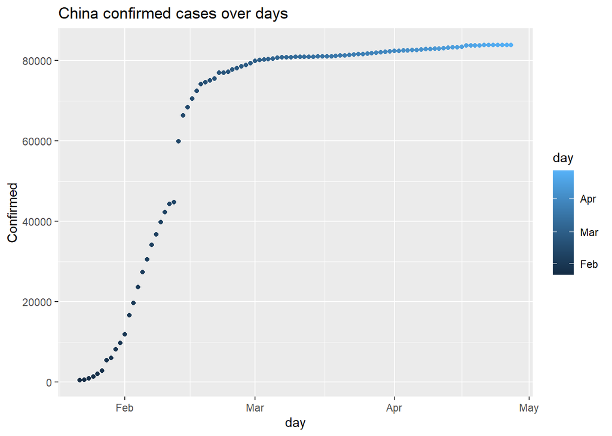

```r
g1 <- ggplot(China, aes(day, Confirmed))
g1 + geom_point(aes(col = day)) +
  labs(title = "China confirmed cases over days")
```

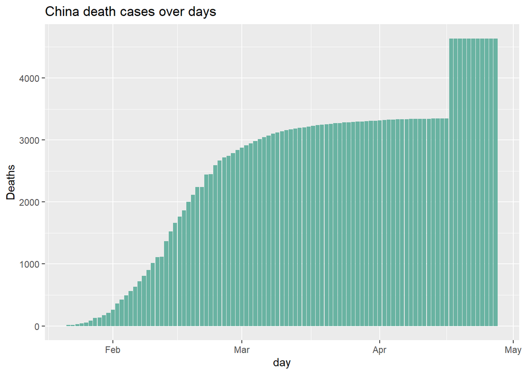

```r
g2 <- ggplot(China, aes(day, Deaths))
g2 + geom_col(fill="#69b3a2") +
  labs(title = "China death cases over days")
```

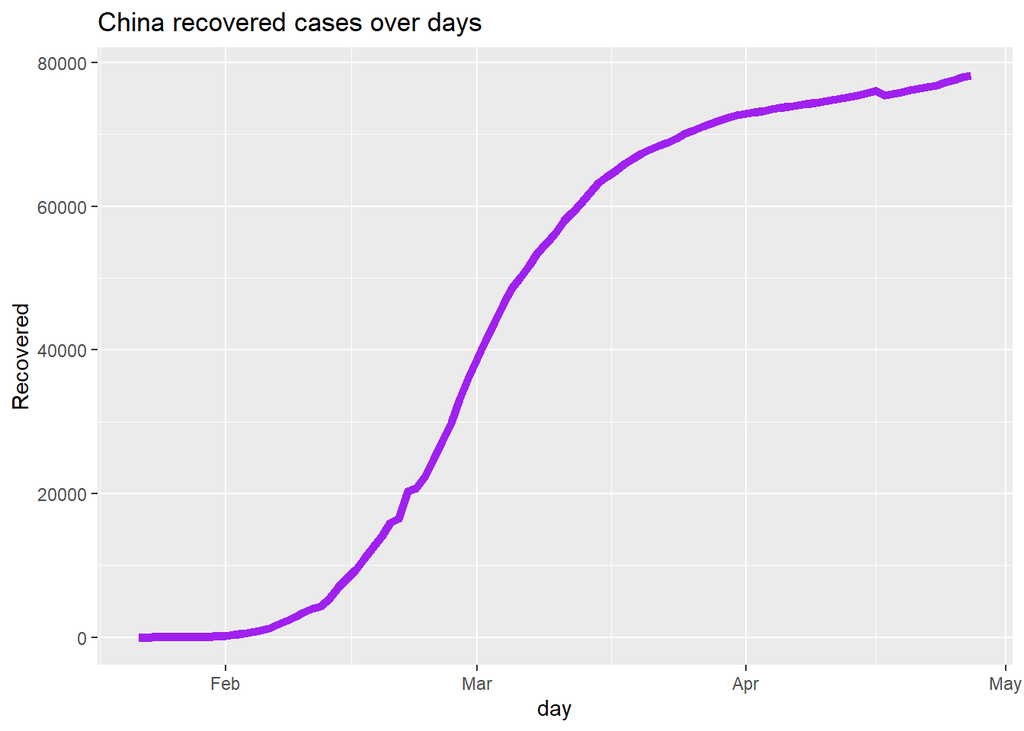

```r
g3 <- ggplot(China, aes(day,Recovered))
g3 + geom_line(col = "purple", size = 2) +
  labs(title = "China recovered cases over days")
```

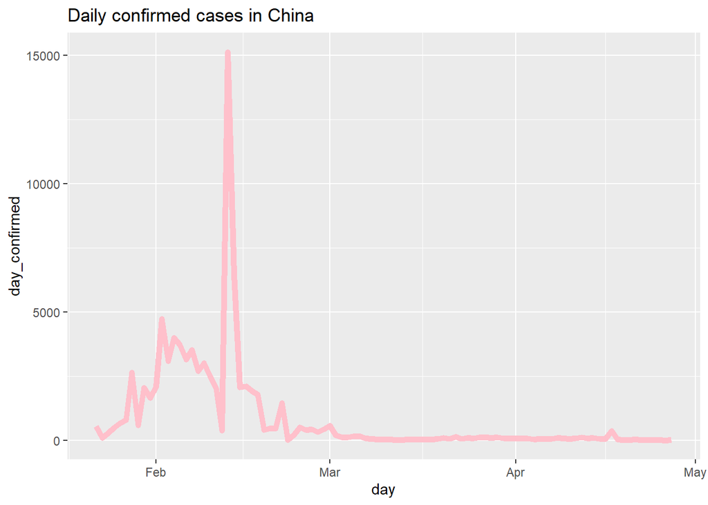

```r
g4 <-ggplot(China, aes(day, day_confirmed))
g4 + geom_line(col = "pink", size = 2) +
  labs(title = "Daily confirmed cases in China")
```

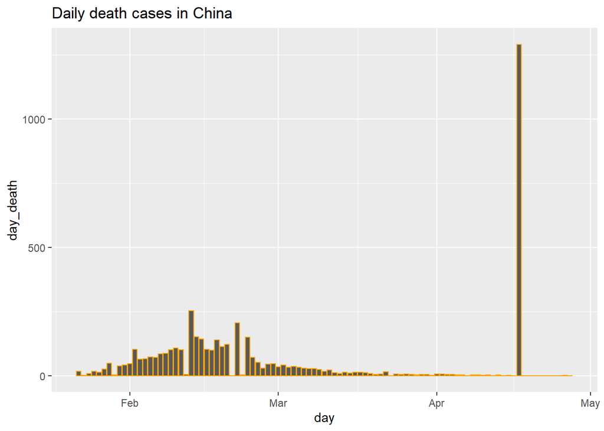

```r
g5 <- ggplot(China, aes(day, day_death))
g5 + geom_col(col = "orange", size = 0.5) +
  labs(title = "Daily death cases in China")
```

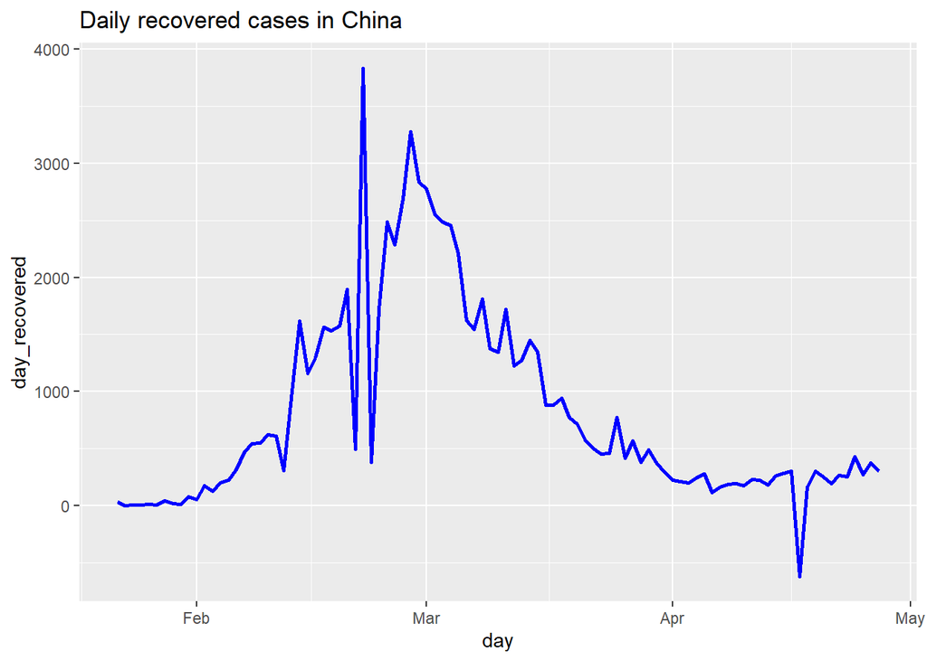

```r
g6 <- ggplot(China, aes(day, day_recovered))
g6 + geom_line(col = "blue", size = 1) +
  labs(title = "Daily recovered cases in China")   ##there's a negative recovered day
```

```r
#trace back see how that happened
China[which(China$day_recovered < 0), ]
```

```
##    Confirmed Deaths Recovered day_confirmed day_death day_recovered        day
## 87     83760   4636     75449           357      1290          -621 2020-04-17
##         categories target
## 87 No action taken     No
```

```r
#switch these rows to NAs because the recovered cases spiked up in these days, then got adjusted
#back down
China[84:86, c(3,6)] <- NA
#re-adjust daily recovered cases for day 87
China[87, 6] <- China[87, 3] - China[83, 3]
China[83:87,]
```

```
##    Confirmed Deaths Recovered day_confirmed day_death day_recovered        day
## 83     83213   3345     75226            79         2           179 2020-04-13
## 84     83306   3345        NA            93         0            NA 2020-04-14
## 85     83356   3346        NA            50         1            NA 2020-04-15
## 86     83403   3346        NA            47         0            NA 2020-04-16
## 87     83760   4636     75449           357      1290           223 2020-04-17
##                categories target
## 83 Public health measures    Yes
## 84        No action taken     No
## 85      Social distancing     No
## 86        No action taken     No
## 87        No action taken     No
```

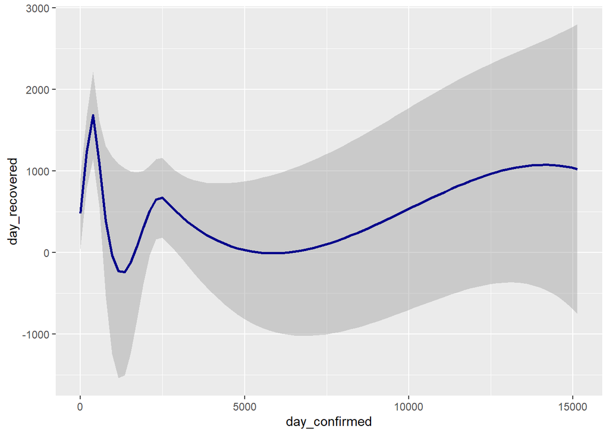

```r
g7 <- ggplot(China, aes(day_confirmed, day_recovered))
g7 + geom_smooth(col = "darkblue")
```

#plot some double plots

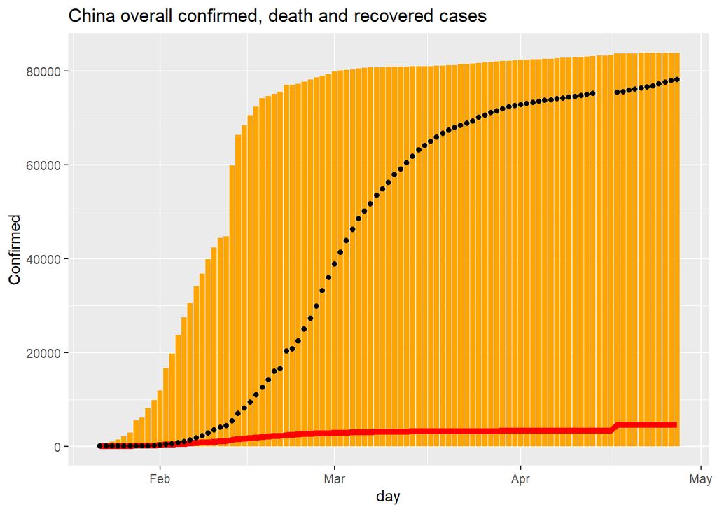

```r
g8 <- ggplot() +

  geom_col(data = China, aes(x = day, y = Confirmed), fill = "orange") +
  geom_line(data = China, aes(x = day, y = Deaths),
            colour = "red", size = 2) +
  geom_point(data = China, aes(x = day, y=Recovered)) +
  labs(title = "China overall confirmed, death and recovered cases")

plot(g8)
```

#category

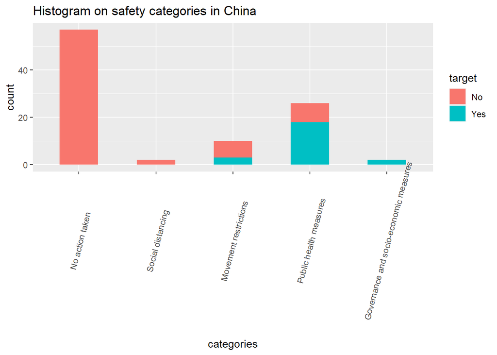

```r
g9 <- ggplot(data = China, aes(categories))
g9 + geom_bar(aes(fill=target), width = 0.5) +
  theme(axis.text.x = element_text(angle=75, vjust=0.6)) +
  labs(title="Histogram on safety categories in China")
```

#targeted_pop_group

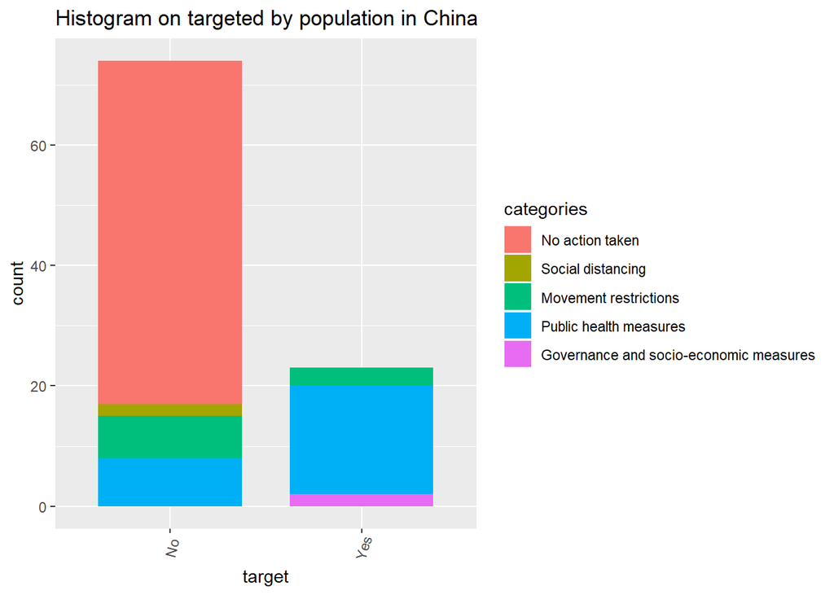

```r
g10 <- ggplot(China, aes(target))
g10 + geom_bar(aes(fill=categories), width = 0.75) +
  theme(axis.text.x = element_text(angle=75, vjust=0.6)) +
  labs(title="Histogram on targeted by population in China")
```

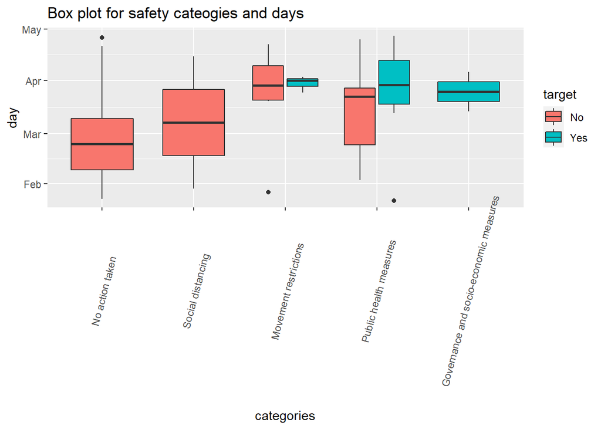

```r
g11 <- ggplot(China, aes(categories,day))
g11 + geom_boxplot(aes(fill = target))+
  theme(axis.text.x = element_text(angle=75, vjust=0.6))+
  labs(title = "Box plot for safety cateogies and days")
```

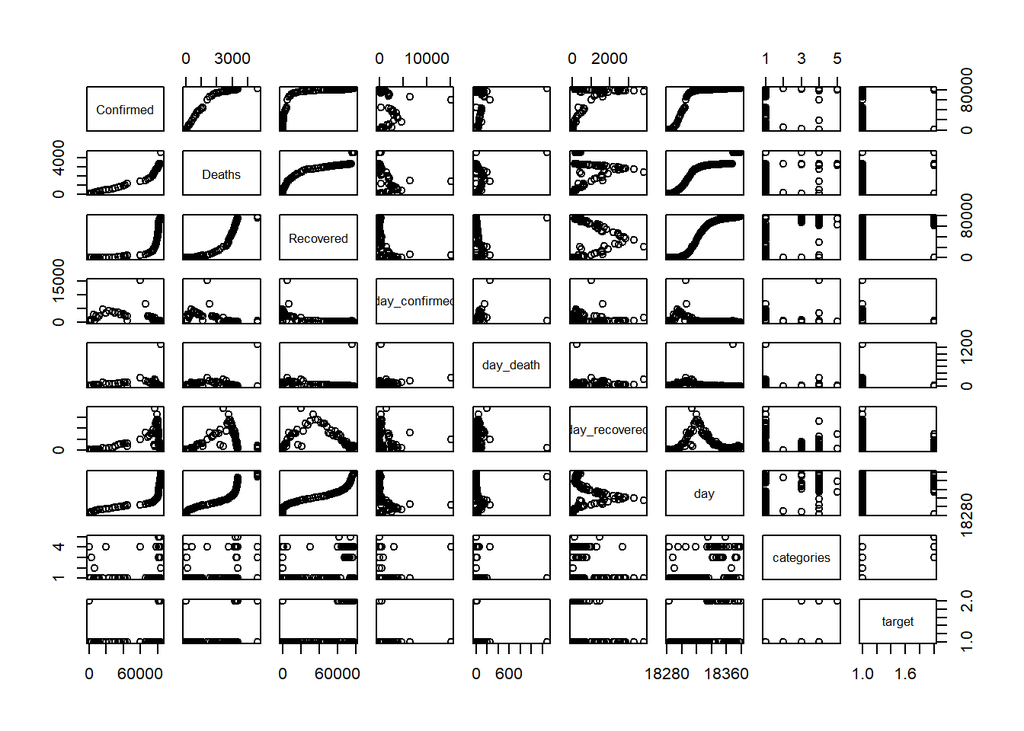

```r
plot(China)
```

#correlation plot

```r
china_numeric <- China[, -c(7, 8, 9)]
china_numeric$categories <- as.numeric(China$categories)
china_numeric$target <- as.numeric(China$target)

c <- cor(china_numeric, use = "pairwise.complete.obs", method = "spearman")
c
```

```
##                 Confirmed      Deaths   Recovered day_confirmed  day_death
## Confirmed      1.00000000  0.99958241  0.99999639  -0.786274098 -0.7083972
## Deaths         0.99958241  1.00000000  0.99954474  -0.783178872 -0.7026945
## Recovered      0.99999639  0.99954474  1.00000000  -0.789142482 -0.6880866
## day_confirmed -0.78627410 -0.78317887 -0.78914248   1.000000000  0.7414348
## day_death     -0.70839720 -0.70269453 -0.68808664   0.741434820  1.0000000
## day_recovered -0.02419588 -0.02550786 -0.02414539   0.006025641  0.4391924
## categories     0.42771581  0.42223013  0.46376792  -0.372981789 -0.4458320
## target         0.38523186  0.38279464  0.42681697  -0.369226317 -0.3548389
##               day_recovered categories     target
## Confirmed      -0.024195879  0.4277158  0.3852319
## Deaths         -0.025507865  0.4222301  0.3827946
## Recovered      -0.024145393  0.4637679  0.4268170
## day_confirmed   0.006025641 -0.3729818 -0.3692263
## day_death       0.439192385 -0.4458320 -0.3548389
## day_recovered   1.000000000 -0.1861505 -0.1395388
## categories     -0.186150481  1.0000000  0.7312613
## target         -0.139538837  0.7312613  1.0000000
```

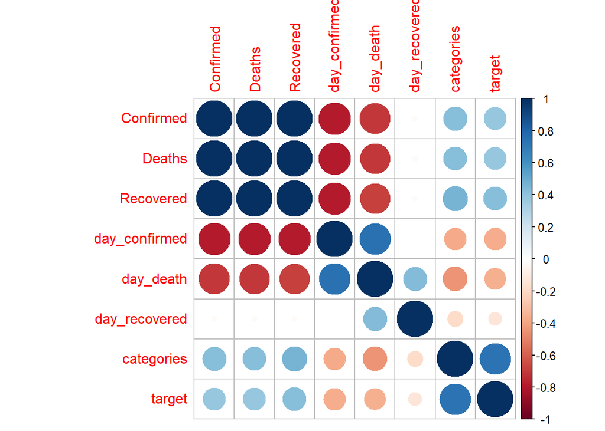

```r
corrplot(c)
```

Data Modeling: trying 3 dataframes with multiple modeling methods including linear regression, rpart, knn, svmRadial and random forest

1. China

```r
china_na <- na.omit(China)
is.na(china_na)
```

```
##    Confirmed Deaths Recovered day_confirmed day_death day_recovered   day
## 1      FALSE  FALSE     FALSE         FALSE     FALSE         FALSE FALSE
## 2      FALSE  FALSE     FALSE         FALSE     FALSE         FALSE FALSE
## 3      FALSE  FALSE     FALSE         FALSE     FALSE         FALSE FALSE
## 4      FALSE  FALSE     FALSE         FALSE     FALSE         FALSE FALSE
## 5      FALSE  FALSE     FALSE         FALSE     FALSE         FALSE FALSE
## 6      FALSE  FALSE     FALSE         FALSE     FALSE         FALSE FALSE
## 7      FALSE  FALSE     FALSE         FALSE     FALSE         FALSE FALSE
## 8      FALSE  FALSE     FALSE         FALSE     FALSE         FALSE FALSE
## 9      FALSE  FALSE     FALSE         FALSE     FALSE         FALSE FALSE
## 10     FALSE  FALSE     FALSE         FALSE     FALSE         FALSE FALSE
## 11     FALSE  FALSE     FALSE         FALSE     FALSE         FALSE FALSE
## 12     FALSE  FALSE     FALSE         FALSE     FALSE         FALSE FALSE
## 13     FALSE  FALSE     FALSE         FALSE     FALSE         FALSE FALSE
## 14     FALSE  FALSE     FALSE         FALSE     FALSE         FALSE FALSE
```

[output cut: 175 more lines]

```r
set.seed(3033)
intrain <- createDataPartition(y = china_na$Confirmed, p= 0.7, list = FALSE)
training <- china_na[intrain,]
testing <- china_na[-intrain,]
dim(intrain); dim(training); dim(testing)
```

```
## [1] 68  1
```

```
## [1] 68  9
```

```
## [1] 26  9
```

#linear regression

```r
fit_all <- lm(Confirmed~ ., data = training)
summary(fit_all)
```

```
##
## Call:
## lm(formula = Confirmed ~ ., data = training)
##
## Residuals:
##      Min       1Q   Median       3Q      Max
## -17582.7  -5228.9    666.6   5575.6  17605.4
##
## Coefficients:
##                                                    Estimate Std. Error t value
## (Intercept)                                       4.283e+06  4.502e+06   0.951
## Deaths                                            2.018e+01  4.406e+00   4.580
## Recovered                                         1.882e-01  1.542e-01   1.221
## day_confirmed                                     1.980e+00  7.244e-01   2.734
## day_death                                        -1.153e+01  7.806e+00  -1.478
## day_recovered                                     5.687e+00  2.304e+00   2.468
## day                                              -2.335e+02  2.462e+02  -0.949
## categoriesMovement restrictions                  -2.038e+03  4.898e+03  -0.416
## categoriesPublic health measures                 -4.955e+03  4.417e+03  -1.122
## categoriesGovernance and socio-economic measures  4.153e+03  1.056e+04   0.393
## targetYes                                         1.137e+03  4.164e+03   0.273
##                                                  Pr(>|t|)
## (Intercept)                                       0.34548
## Deaths                                           2.57e-05 ***
## Recovered                                         0.22729
## day_confirmed                                     0.00833 **
## day_death                                         0.14503
## day_recovered                                     0.01661 *
## day                                               0.34684
## categoriesMovement restrictions                   0.67899
## categoriesPublic health measures                  0.26664
## categoriesGovernance and socio-economic measures  0.69553
## targetYes                                         0.78583
## ---
## Signif. codes:  0 '***' 0.001 '**' 0.01 '*' 0.05 '.' 0.1 ' ' 1
##
## Residual standard error: 9229 on 57 degrees of freedom
## Multiple R-squared:  0.8984, Adjusted R-squared:  0.8806
## F-statistic: 50.42 on 10 and 57 DF,  p-value: < 2.2e-16
```

```r
fit_null <- lm(Confirmed ~ 1, data = training)

fit_step <- step(fit_null, scope=list(lower=fit_null, upper=fit_all),direction="both")
```

```
## Start:  AIC=1387.21
## Confirmed ~ 1
##
##                 Df  Sum of Sq        RSS    AIC
## + Deaths         1 3.9458e+10 8.3426e+09 1270.5
## + Recovered      1 2.9979e+10 1.7822e+10 1322.1
## + day            1 2.9635e+10 1.8166e+10 1323.4
## + day_confirmed  1 5.8018e+09 4.1999e+10 1380.4
## + day_recovered  1 5.6269e+09 4.2174e+10 1380.7
## + target         1 2.3715e+09 4.5429e+10 1385.8
## + categories     3 4.0861e+09 4.3715e+10 1387.1
## <none>                        4.7801e+10 1387.2
## + day_death      1 6.1190e+04 4.7801e+10 1389.2
##
## Step:  AIC=1270.51
## Confirmed ~ Deaths
##
##                 Df  Sum of Sq        RSS    AIC
## + day_recovered  1 2.6839e+09 5.6587e+09 1246.1
## + day            1 1.6677e+09 6.6749e+09 1257.3
## + Recovered      1 6.5434e+08 7.6882e+09 1267.0
## + day_confirmed  1 4.4003e+08 7.9025e+09 1268.8
## + target         1 2.8619e+08 8.0564e+09 1270.1
## <none>                        8.3426e+09 1270.5
## + day_death      1 3.8675e+07 8.3039e+09 1272.2
## + categories     3 4.9730e+08 7.8453e+09 1272.3
## - Deaths         1 3.9458e+10 4.7801e+10 1387.2
##
## Step:  AIC=1246.11
## Confirmed ~ Deaths + day_recovered
##
##                 Df  Sum of Sq        RSS    AIC
## + day_confirmed  1 3.2766e+08 5.3310e+09 1244.1
## <none>                        5.6587e+09 1246.1
## + day_death      1 7.2310e+07 5.5864e+09 1247.2
## + Recovered      1 1.9575e+07 5.6391e+09 1247.9
## + day            1 4.2206e+06 5.6545e+09 1248.1
## + target         1 3.1413e+06 5.6555e+09 1248.1
## + categories     3 8.2694e+07 5.5760e+09 1251.1
## - day_recovered  1 2.6839e+09 8.3426e+09 1270.5
```

[output cut: 14 more lines]

```
## - Deaths         1 3.1127e+10 3.6458e+10 1372.8
##
## Step:  AIC=1243.63
## Confirmed ~ Deaths + day_recovered + day_confirmed + day_death
##
##                 Df  Sum of Sq        RSS    AIC
## <none>                        5.1438e+09 1243.6
## - day_death      1 1.8718e+08 5.3310e+09 1244.1
## + Recovered      1 4.6092e+07 5.0977e+09 1245.0
## + target         1 8.1545e+06 5.1357e+09 1245.5
## + day            1 3.6310e+06 5.1402e+09 1245.6
## - day_confirmed  1 4.4253e+08 5.5864e+09 1247.2
## + categories     3 1.4416e+08 4.9997e+09 1247.7
## - day_recovered  1 2.6114e+09 7.7553e+09 1269.5
## - Deaths         1 3.1138e+10 3.6282e+10 1374.5
```

```r
summary(fit_step)
```

```
##
## Call:
## lm(formula = Confirmed ~ Deaths + day_recovered + day_confirmed +
##     day_death, data = training)
##
## Residuals:
##    Min     1Q Median     3Q    Max
## -17832  -5657   1250   6196  17533
##
## Coefficients:
##                 Estimate Std. Error t value Pr(>|t|)
## (Intercept)   12048.7519  3018.9598   3.991 0.000174 ***
## Deaths           18.6991     0.9575  19.529  < 2e-16 ***
## day_recovered     6.9953     1.2369   5.655 4.05e-07 ***
## day_confirmed     1.3901     0.5971   2.328 0.023132 *
## day_death       -10.7900     7.1263  -1.514 0.135002
## ---
## Signif. codes:  0 '***' 0.001 '**' 0.01 '*' 0.05 '.' 0.1 ' ' 1
##
## Residual standard error: 9036 on 63 degrees of freedom
## Multiple R-squared:  0.8924, Adjusted R-squared:  0.8856
## F-statistic: 130.6 on 4 and 63 DF,  p-value: < 2.2e-16
```

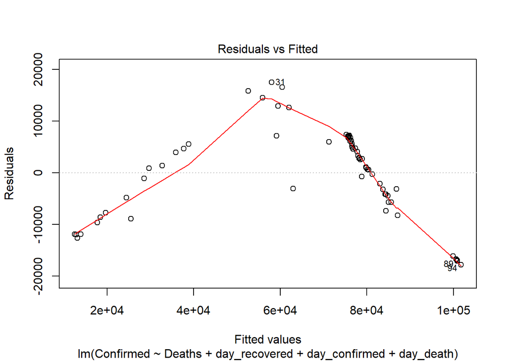

```r
#adjusted R-squred of 0.89, really high

plot(fit_step, 1) #very bad, seems to show a trend
```

```r
p <- predict(fit_step, testing, type = "response")
p
```

```
##         4         6         7         8        14        18        22        28
##  13351.06  14465.37  17901.20  15415.56  27436.85  33699.07  35554.70  61197.13
##        30        35        37        45        47        49        53        57
##  66466.57  79243.79  82539.01  80235.77  82455.81  80004.63  81781.20  79170.42
##        60        62        67        71        72        82        90        91
##  76987.99  76497.91  76504.55  75625.24  75648.99  76286.45 100503.06 100123.71
##        93        96
## 100543.60 101358.88
```

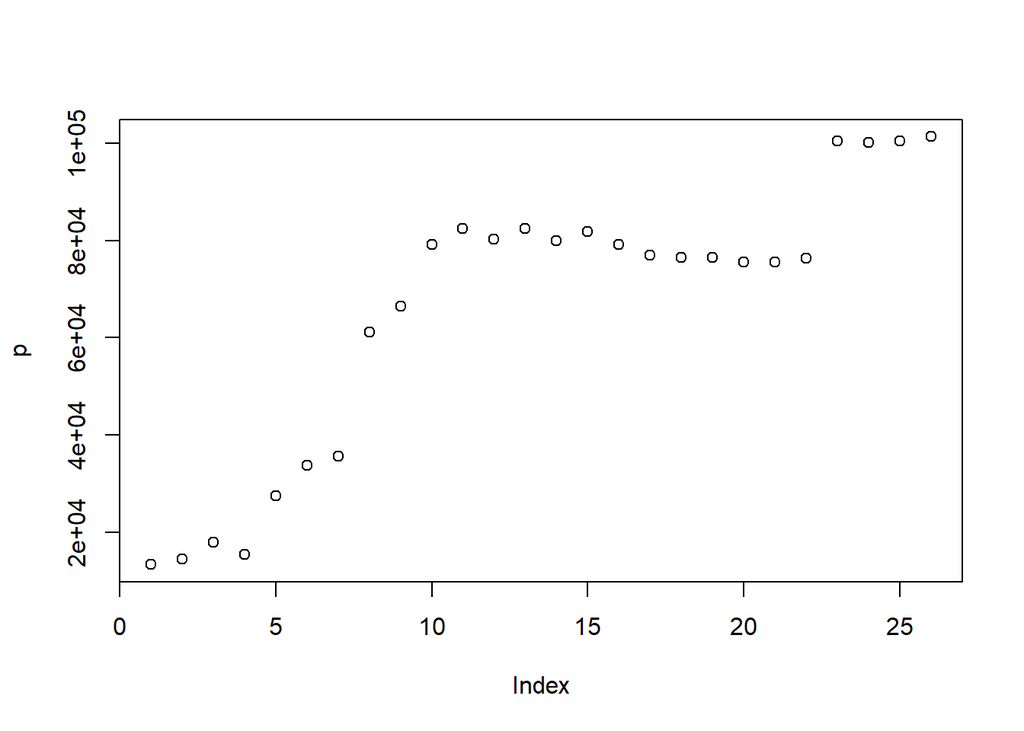

```r
plot(p)
```

#try different models to find the best one

```r
trctrl <- trainControl(method = "repeatedcv", number = 10, repeats = 3)
grid <- expand.grid(C = seq(0, 2, length =20))
```

#RPART

```r
set.seed(3233)
fit.cart <- train(Confirmed~., data = training, method = "rpart",
                  preProcess = c("center", "scale"),
                  trControl = trctrl)
fit.cart
```

```
## CART
##
## 68 samples
##  8 predictor
##
## Pre-processing: centered (12), scaled (12)
## Resampling: Cross-Validated (10 fold, repeated 3 times)
## Summary of sample sizes: 61, 62, 61, 61, 61, 61, ...
## Resampling results across tuning parameters:
##
##   cp          RMSE       Rsquared   MAE
##   0.00193264   7752.634  0.9568024   4708.236
##   0.01772864   8401.955  0.9345085   5458.659
##   0.90003530  20310.200  0.8883858  15584.166
##
## RMSE was used to select the optimal model using the smallest value.
## The final value used for the model was cp = 0.00193264.
```

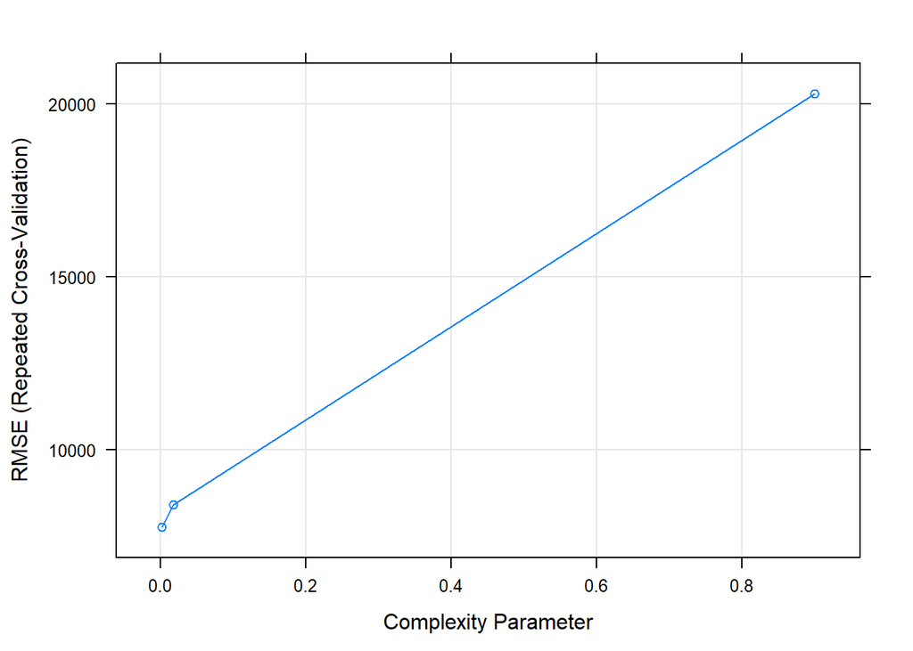

```r
plot(fit.cart)
```

# kNN

```r
set.seed(3233)
fit.knn <- train(Confirmed~., data = training, method = "knn",
                 preProcess = c("center", "scale"),
                 trControl = trctrl,
                 tuneLength = 10)
fit.knn
```

```
## k-Nearest Neighbors
##
## 68 samples
##  8 predictor
##
## Pre-processing: centered (12), scaled (12)
## Resampling: Cross-Validated (10 fold, repeated 3 times)
## Summary of sample sizes: 61, 62, 61, 61, 61, 61, ...
## Resampling results across tuning parameters:
##
##   k   RMSE       Rsquared   MAE
##    5   4935.009  0.9555982  2917.959
##    7   6160.512  0.9453151  3671.773
##    9   7196.279  0.9419349  4397.712
##   11   8181.329  0.9258218  4815.245
##   13   9846.702  0.8986533  5726.155
##   15  11299.885  0.8750643  6514.497
##   17  12332.184  0.8536971  7145.340
##   19  13168.300  0.8401744  7638.804
##   21  13690.292  0.8220749  8175.370
##   23  14783.893  0.7965162  8990.370
##
## RMSE was used to select the optimal model using the smallest value.
## The final value used for the model was k = 5.
```

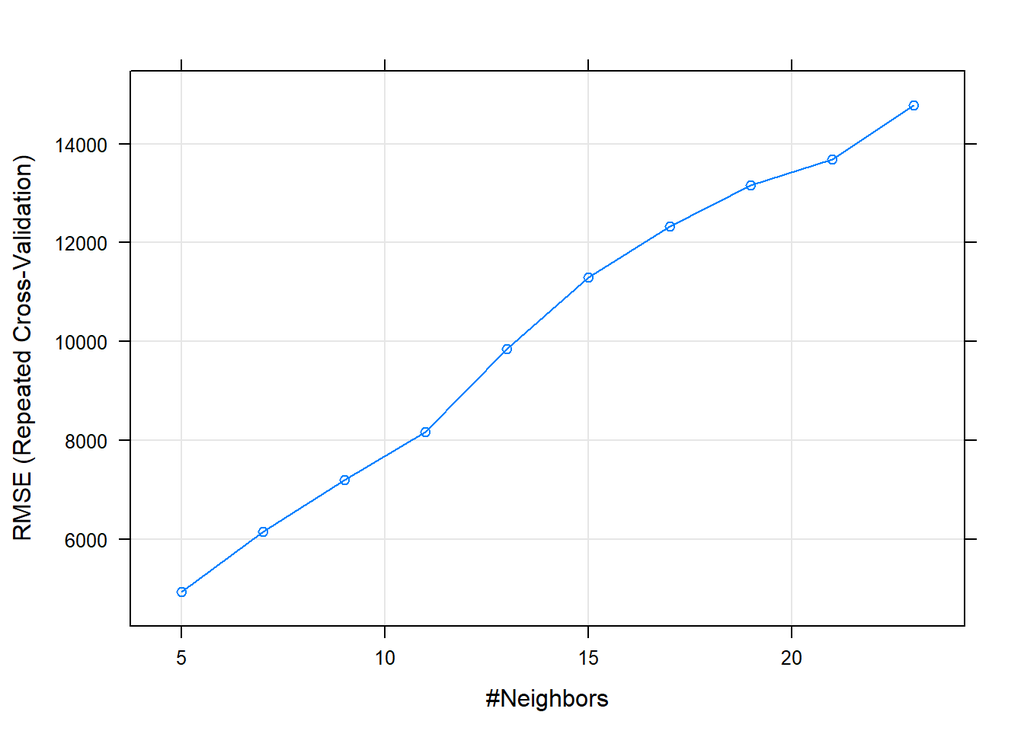

```r
plot(fit.knn)
```

```r
#performance slightly better than rpart, but not that much better
```

#SVMRadial

```r
trctrl_rbf <- trainControl(method = "repeatedcv", number = 5, repeats = 3)
svmGrid <- expand.grid(sigma= 2^c(-15,-10, -5, 0), C= 2^c(0:5))

set.seed(3233)

svm_Radial <- train(Confirmed ~., data = training, method = "svmRadial",
                    trControl=trctrl_rbf,
                    preProcess = c("center", "scale"),
                    tuneGrid = svmGrid,
                    tuneLength = 10)

svm_Radial   #extrememly high RMSE and MAE
```

```
## Support Vector Machines with Radial Basis Function Kernel
##
## 68 samples
##  8 predictor
##
## Pre-processing: centered (12), scaled (12)
## Resampling: Cross-Validated (5 fold, repeated 3 times)
## Summary of sample sizes: 54, 54, 55, 56, 53, 55, ...
## Resampling results across tuning parameters:
##
##   sigma         C   RMSE      Rsquared   MAE
##   3.051758e-05   1  29730.69  0.4543596  15778.02
##   3.051758e-05   2  29730.69  0.4543596  15778.01
##   3.051758e-05   4  29730.67  0.4543596  15777.99
##   3.051758e-05   8  29730.64  0.4543596  15777.96
##   3.051758e-05  16  29730.59  0.4543596  15777.88
##   3.051758e-05  32  29730.47  0.4543596  15777.73
##   9.765625e-04   1  29730.48  0.4787019  15777.73
##   9.765625e-04   2  29730.26  0.4787019  15777.42
##   9.765625e-04   4  29729.82  0.4787019  15776.82
##   9.765625e-04   8  29728.94  0.4787019  15775.61
##   9.765625e-04  16  29727.19  0.4787019  15773.18
##   9.765625e-04  32  29723.67  0.4787019  15768.33
##   3.125000e-02   1  29726.99  0.4940416  15772.24
##   3.125000e-02   2  29723.28  0.4940416  15766.46
##   3.125000e-02   4  29715.85  0.4943302  15754.90
##   3.125000e-02   8  29700.30  0.4945781  15731.69
##   3.125000e-02  16  29668.14  0.4969752  15685.49
##   3.125000e-02  32  29588.34  0.5075990  15595.21
##   1.000000e+00   1  29728.81  0.2951164  15775.34
##   1.000000e+00   2  29726.92  0.2951164  15772.66
##   1.000000e+00   4  29723.14  0.2951164  15767.28
##   1.000000e+00   8  29714.96  0.2970062  15756.28
##   1.000000e+00  16  29698.11  0.2970062  15734.13
##   1.000000e+00  32  29663.19  0.2981505  15689.90
##
## RMSE was used to select the optimal model using the smallest value.
## The final values used for the model were sigma = 0.03125 and C = 32.
```

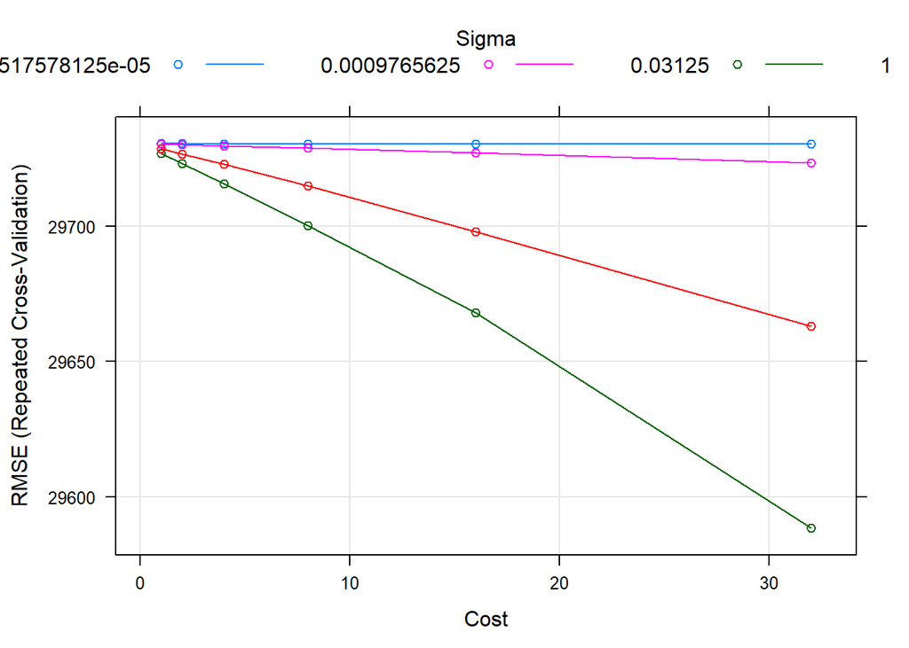

```r
plot(svm_Radial)
```

```r
test_pred <- predict(svm_Radial, newdata = testing)
test_pred
```

```
##  [1] 80445.94 80615.42 80421.56 80463.81 80427.04 80436.98 80506.30 80506.24
##  [9] 80542.45 80586.71 80699.11 80731.05 80742.88 80779.23 80849.40 81010.23
## [17] 80955.39 80975.45 81064.40 81035.28 81082.51 81104.13 81057.68 81040.00
## [25] 81153.25 81046.00
```

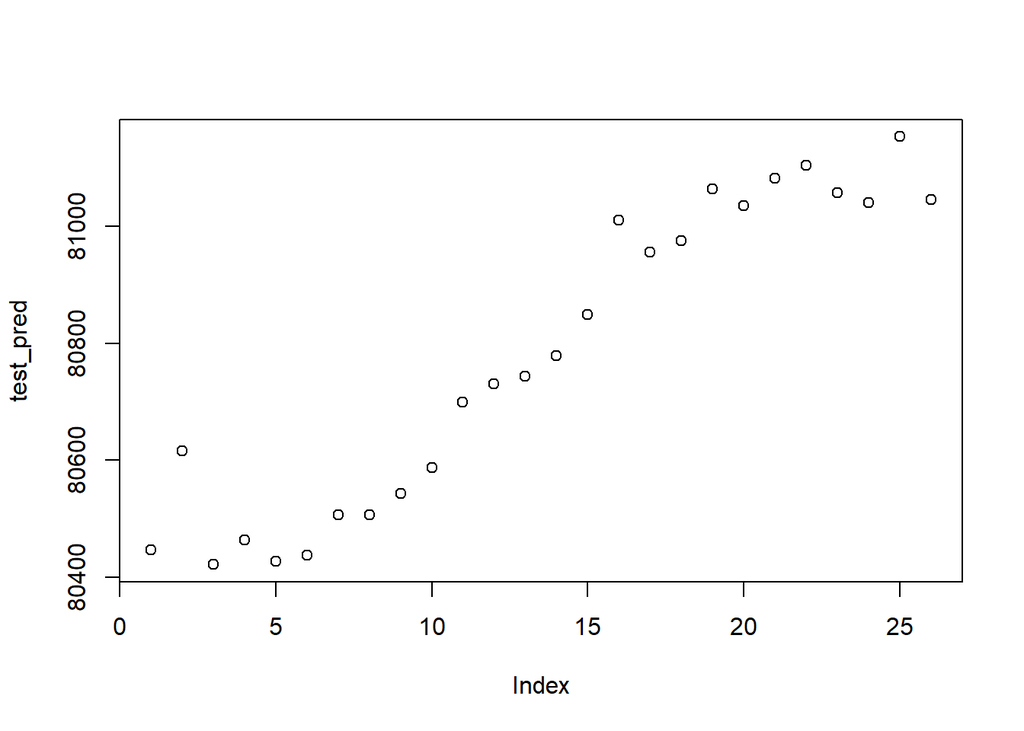

```r
plot(test_pred)
```

#Random Forest

```r
#using random search
trctrl_rf <- trainControl(method="repeatedcv", number=10, repeats=3, search="random")
set.seed(3233)
mtry <- sqrt(ncol(training))
tunegrid <- expand.grid(.mtry=mtry)
rf_gridsearch <- train(Confirmed ~ ., data = training, method="rf",
                       trControl=trctrl_rf,
                       preProcess = c("center", "scale"),
                       tuneLength = 15)
print(rf_gridsearch) #best result so far  1518.527  0.9979277   873.7642
```

```
## Random Forest
##
## 68 samples
##  8 predictor
##
## Pre-processing: centered (12), scaled (12)
## Resampling: Cross-Validated (10 fold, repeated 3 times)
## Summary of sample sizes: 61, 62, 61, 61, 61, 61, ...
## Resampling results across tuning parameters:
##
##   mtry  RMSE       Rsquared   MAE
##    1    12314.115  0.9763611  9520.1094
##    4     2162.216  0.9967732  1261.1794
##    5     1849.961  0.9972736  1105.7770
##    6     1659.514  0.9978314   970.8995
##    7     1559.231  0.9979454   902.3161
##    8     1570.889  0.9977311   901.3040
##   10     1518.527  0.9979277   873.7642
##   11     1533.883  0.9977180   886.1724
##   12     1596.412  0.9973951   915.6598
##
## RMSE was used to select the optimal model using the smallest value.
## The final value used for the model was mtry = 10.
```

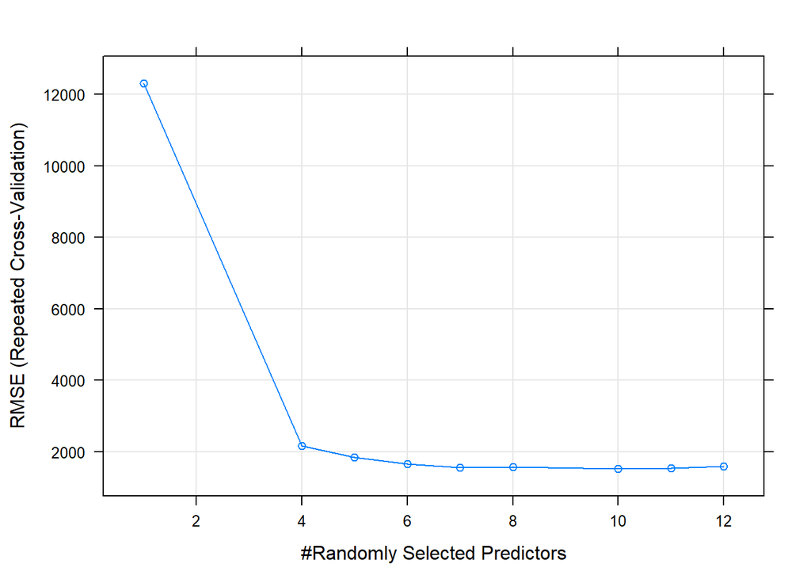

```r
plot(rf_gridsearch)
```

```r
test_pred <- predict(rf_gridsearch, newdata = testing)
test_pred
```

```
##         4         6         7         8        14        18        22        28
##  2097.291  2349.769  8808.723  5524.554 21253.416 38204.245 43185.006 71551.252
##        30        35        37        45        47        49        53        57
## 75236.750 77736.926 78533.872 80665.146 80795.686 80917.673 80974.486 81083.330
##        60        62        67        71        72        82        90        91
## 81422.369 81600.516 82006.135 82348.376 82498.641 83068.856 83841.590 83764.871
##        93        96
## 83876.213 83839.507
```

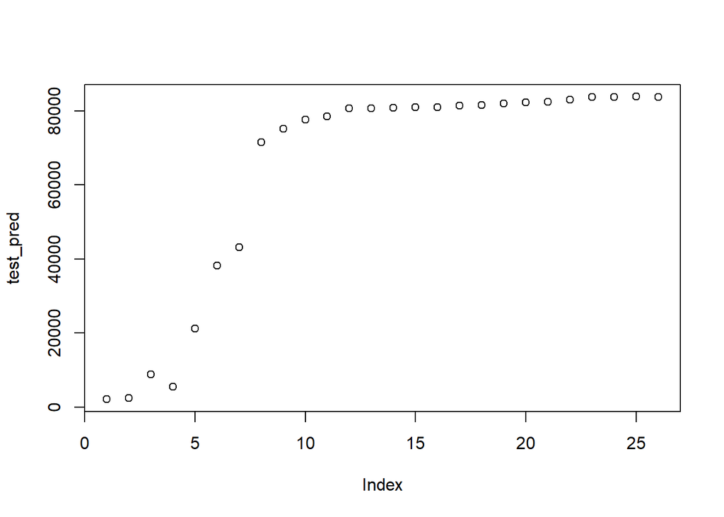

```r
plot(test_pred)
```

#For China dataset, random forest using random search produced the best result. #Use this method to predict the entire dataset:

```r
china_pred <- predict(rf_gridsearch, newdata = China)
china_pred
```

```
##         1         2         3         4         5         6         7         8
##  2109.345  1994.148  2036.518  2097.291  2323.248  2349.769  8808.723  5524.554
##         9        10        11        12        13        14        15        16
##  8922.351 10455.862 11074.905 17479.142 17027.210 21253.416 29794.891 32094.502
##        17        18        19        20        21        22        23        24
## 33297.373 38204.245 38878.845 40033.224 39953.831 43185.006 60073.309 67064.334
##        25        26        27        28        29        30        31        32
## 67648.249 69137.273 70221.562 71551.252 74454.562 75236.750 75486.325 76907.003
##        33        34        35        36        37        38        39        40
## 77207.574 77240.055 77736.926 78030.730 78533.872 78865.653 79277.927 79831.178
##        41        42        43        44        45        46        47        48
## 80097.957 80235.246 80293.125 80388.817 80665.146 80755.246 80795.686 80882.632
##        49        50        51        52        53        54        55        56
## 80917.673 80914.219 80940.773 80955.033 80974.486 81003.295 81042.201 81051.874
##        57        58        59        60        61        62        63        64
## 81083.330 81191.784 81329.028 81422.369 81492.001 81600.516 81656.216 81614.710
##        65        66        67        68        69        70        71        72
## 81796.850 81807.848 82006.135 82123.725 82227.832 82294.163 82348.376 82498.641
##        73        74        75        76        77        78        79        80
## 82555.791 82597.568 82594.823 82672.687 82723.831 82786.367 82892.236 82914.635
##        81        82        83        87        88        89        90        91
## 82950.622 83068.856 83165.459 83636.180 83760.498 83808.714 83841.590 83764.871
##        92        93        94        95        96        97
## 83871.062 83876.213 83801.490 83885.032 83839.507 83884.472
```

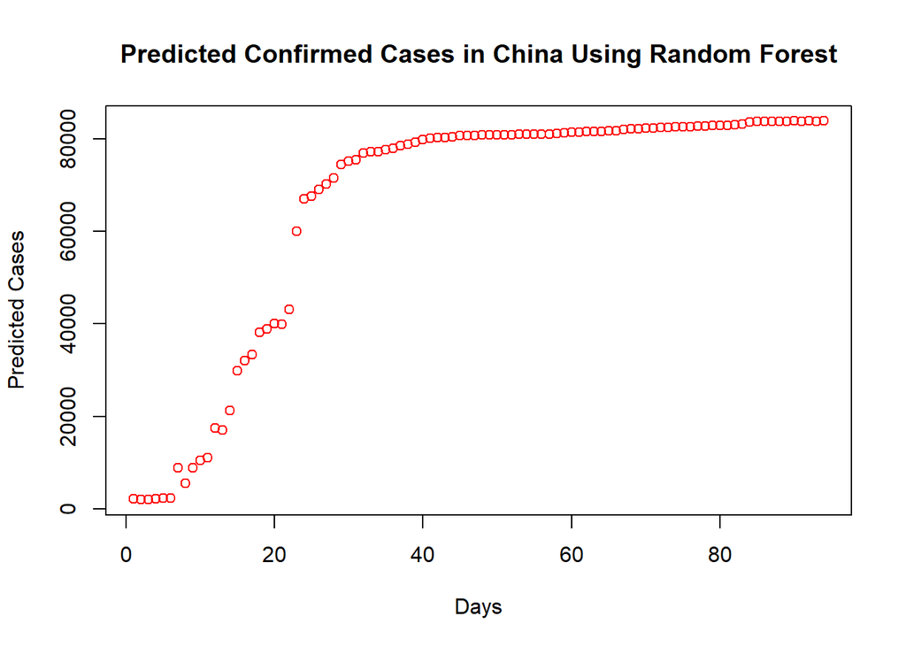

```r
plot(china_pred, main = "Predicted Confirmed Cases in China Using Random Forest", xlab = "Days",
     ylab = "Predicted Cases", col = "red")
```

2. China with Confirmed, Deaths, Recovered, dates, Category and Target

```r
China_2 <- China[, -c(4, 5, 6)]
China_2
```

```
##    Confirmed Deaths Recovered        day                             categories
## 1        548     17        28 2020-01-22                 Public health measures
## 2        643     18        28 2020-01-23                        No action taken
## 3        920     26        33 2020-01-24                        No action taken
## 4       1406     42        35 2020-01-25                        No action taken
## 5       2075     56        45 2020-01-26                        No action taken
## 6       2877     82        52 2020-01-27                  Movement restrictions
## 7       5509    131        91 2020-01-28                        No action taken
## 8       6087    133       105 2020-01-29                      Social distancing
## 9       8141    171       114 2020-01-30                        No action taken
## 10      9802    213       189 2020-01-31                        No action taken
## 11     11891    259       239 2020-02-01                        No action taken
## 12     16630    361       414 2020-02-02                        No action taken
## 13     19716    425       541 2020-02-03                 Public health measures
## 14     23707    491       737 2020-02-04                        No action taken
```

[output cut: 181 more lines]

```r
China_2 <- na.omit(China_2)

set.seed(3033)
intrain <- createDataPartition(y = China_2$Confirmed, p= 0.7, list = FALSE)
training <- China_2[intrain,]
testing <- China_2[-intrain,]
dim(intrain); dim(training); dim(testing)
```

```
## [1] 68  1
```

```
## [1] 68  6
```

```
## [1] 26  6
```

#linear regression

```r
fit_all <- lm(Confirmed~ ., data = training)
summary(fit_all)
```

```
##
## Call:
## lm(formula = Confirmed ~ ., data = training)
##
## Residuals:
##    Min     1Q Median     3Q    Max
## -21563  -3111   1174   6005  16826
##
## Coefficients:
##                                                    Estimate Std. Error t value
## (Intercept)                                       1.040e+07  3.430e+06   3.033
## Deaths                                            2.774e+01  2.966e+00   9.352
## Recovered                                         7.543e-02  1.550e-01   0.487
## day                                              -5.679e+02  1.876e+02  -3.028
## categoriesMovement restrictions                  -4.637e+02  5.228e+03  -0.089
## categoriesPublic health measures                 -1.790e+03  4.409e+03  -0.406
## categoriesGovernance and socio-economic measures  8.846e+03  1.173e+04   0.754
## targetYes                                        -1.546e+03  4.529e+03  -0.341
##                                                  Pr(>|t|)
## (Intercept)                                       0.00358 **
## Deaths                                           2.53e-13 ***
## Recovered                                         0.62830
## day                                               0.00363 **
## categoriesMovement restrictions                   0.92961
## categoriesPublic health measures                  0.68626
## categoriesGovernance and socio-economic measures  0.45389
## targetYes                                         0.73402
## ---
## Signif. codes:  0 '***' 0.001 '**' 0.01 '*' 0.05 '.' 0.1 ' ' 1
##
## Residual standard error: 10400 on 60 degrees of freedom
## Multiple R-squared:  0.8642, Adjusted R-squared:  0.8483
## F-statistic: 54.52 on 7 and 60 DF,  p-value: < 2.2e-16
```

```r
fit_null <- lm(Confirmed ~ 1, data = training)

fit_step <- step(fit_null, scope=list(lower=fit_null, upper=fit_all),direction="both")
```

```
## Start:  AIC=1387.21
## Confirmed ~ 1
##
##              Df  Sum of Sq        RSS    AIC
## + Deaths      1 3.9458e+10 8.3426e+09 1270.5
## + Recovered   1 2.9979e+10 1.7822e+10 1322.1
## + day         1 2.9635e+10 1.8166e+10 1323.4
## + target      1 2.3715e+09 4.5429e+10 1385.8
## + categories  3 4.0861e+09 4.3715e+10 1387.1
## <none>                     4.7801e+10 1387.2
##
## Step:  AIC=1270.51
## Confirmed ~ Deaths
##
##              Df  Sum of Sq        RSS    AIC
## + day         1 1.6677e+09 6.6749e+09 1257.3
## + Recovered   1 6.5434e+08 7.6882e+09 1267.0
## + target      1 2.8619e+08 8.0564e+09 1270.1
## <none>                     8.3426e+09 1270.5
## + categories  3 4.9730e+08 7.8453e+09 1272.3
## - Deaths      1 3.9458e+10 4.7801e+10 1387.2
##
## Step:  AIC=1257.34
## Confirmed ~ Deaths + day
##
##              Df  Sum of Sq        RSS    AIC
## <none>                     6.6749e+09 1257.3
## + target      1 3.3108e+07 6.6418e+09 1259.0
## + Recovered   1 1.2473e+07 6.6624e+09 1259.2
## + categories  3 1.4751e+08 6.5274e+09 1261.8
## - day         1 1.6677e+09 8.3426e+09 1270.5
## - Deaths      1 1.1491e+10 1.8166e+10 1323.4
```

```r
summary(fit_step)
```

```
##
## Call:
## lm(formula = Confirmed ~ Deaths + day, data = training)
##
## Residuals:
##      Min       1Q   Median       3Q      Max
## -21017.1  -1669.4    781.2   6354.9  16405.5
##
## Coefficients:
##               Estimate Std. Error t value Pr(>|t|)
## (Intercept)  9.619e+06  2.382e+06   4.038 0.000145 ***
## Deaths       2.822e+01  2.668e+00  10.578 9.08e-16 ***
## day         -5.251e+02  1.303e+02  -4.030 0.000149 ***
## ---
## Signif. codes:  0 '***' 0.001 '**' 0.01 '*' 0.05 '.' 0.1 ' ' 1
##
## Residual standard error: 10130 on 65 degrees of freedom
## Multiple R-squared:  0.8604, Adjusted R-squared:  0.8561
## F-statistic: 200.2 on 2 and 65 DF,  p-value: < 2.2e-16
```

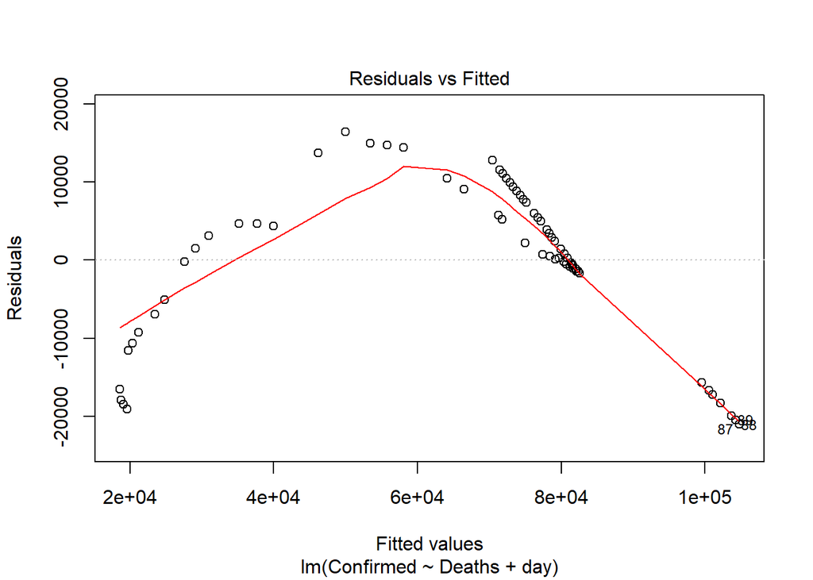

```r
plot(fit_step, 1) #horrible trend but high R-squared
```

```r
p <- predict(fit_step, testing, type = "response")
p
```

```
##         4         6         7         8        14        18        22        28
##  18717.14  18795.80  19653.49  19184.86  26137.05  32897.71  39601.93  61454.00
##        30        35        37        45        47        49        53        57
##  67035.44  76459.84  77695.49  81904.39  82434.55  82484.99  81908.59  81162.87
##        60        62        67        71        72        82        90        91
##  80095.63  79468.80  77548.98  75928.46  75572.71  70914.69 103201.95 102676.89
##        93        96
## 101626.76 100079.80
```

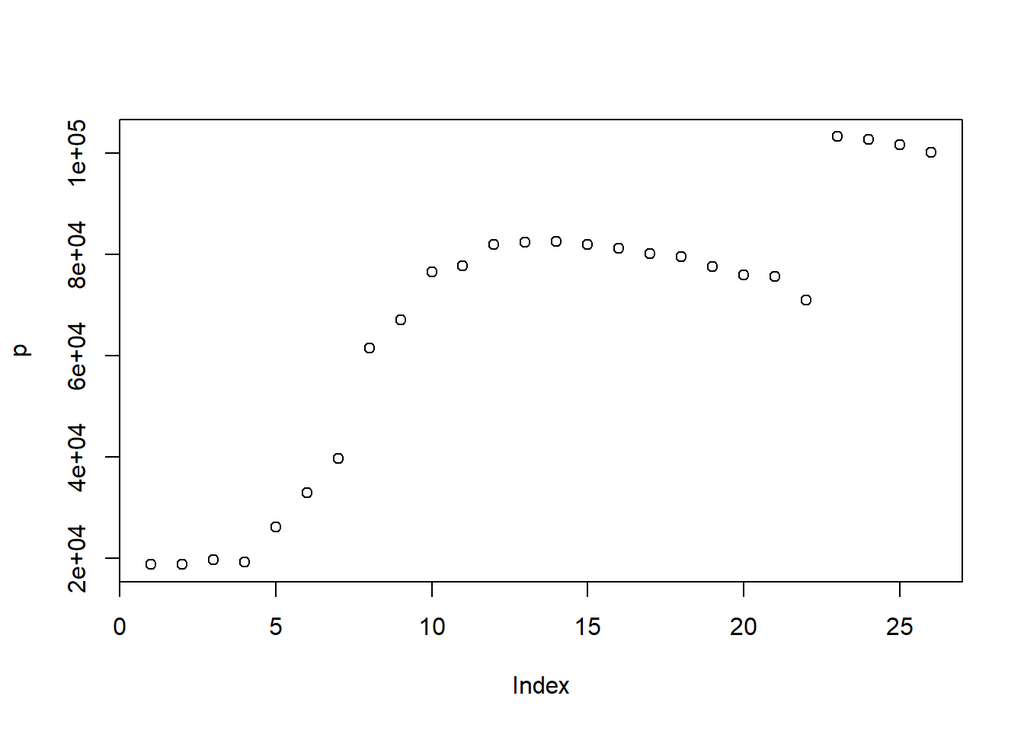

```r
plot(p)
```

#try different models to find the best one

```r
trctrl <- trainControl(method = "repeatedcv", number = 10, repeats = 3)
grid <- expand.grid(C = seq(0, 2, length =20))
```

#RPART

```r
set.seed(3233)
fit.cart <- train(Confirmed ~., data = training, method = "rpart",
                  preProcess = c("center", "scale"),
                  trControl = trctrl)
fit.cart
```

```
## CART
##
## 68 samples
##  5 predictor
##
## Pre-processing: centered (9), scaled (9)
## Resampling: Cross-Validated (10 fold, repeated 3 times)
## Summary of sample sizes: 61, 62, 61, 61, 61, 61, ...
## Resampling results across tuning parameters:
##
##   cp          RMSE       Rsquared   MAE
##   0.00193264   7752.634  0.9568024   4708.236
##   0.01772864   8401.955  0.9345085   5458.659
##   0.90003530  20310.200  0.8883858  15584.166
##
## RMSE was used to select the optimal model using the smallest value.
## The final value used for the model was cp = 0.00193264.
```

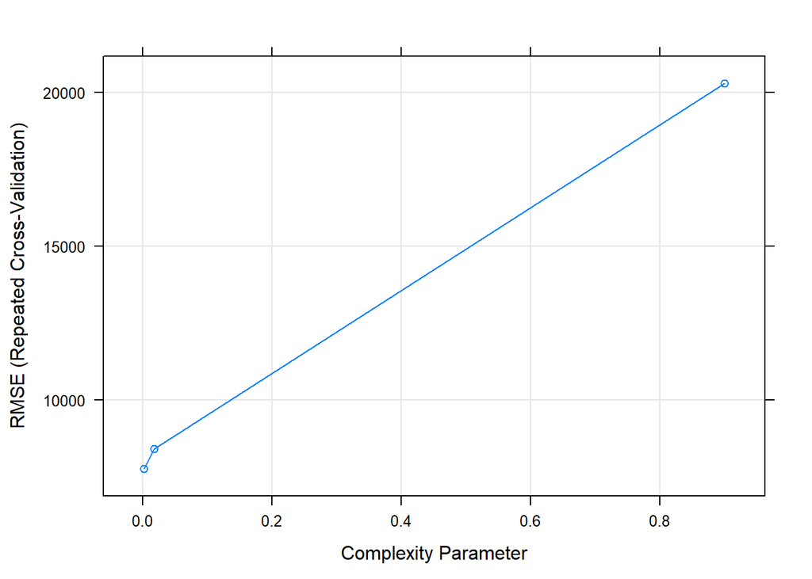

```r
plot(fit.cart)
```

#kNN

```r
set.seed(3233)
fit.knn <- train(Confirmed~., data = training, method = "knn",
                 preProcess = c("center", "scale"),
                 trControl = trctrl,
                 tuneLength = 10)
fit.knn
```

```
## k-Nearest Neighbors
##
## 68 samples
##  5 predictor
##
## Pre-processing: centered (9), scaled (9)
## Resampling: Cross-Validated (10 fold, repeated 3 times)
## Summary of sample sizes: 61, 62, 61, 61, 61, 61, ...
## Resampling results across tuning parameters:
##
##   k   RMSE       Rsquared   MAE
##    5   2829.361  0.9906999  1618.563
##    7   3130.519  0.9912600  1864.604
##    9   4509.424  0.9822874  2622.980
##   11   5766.077  0.9784381  3345.158
##   13   7518.559  0.9668836  4213.030
##   15   9332.838  0.9452424  5172.966
##   17  10988.029  0.9205193  6135.117
##   19  12390.500  0.8971330  6996.311
##   21  13414.978  0.8717724  7685.411
##   23  14617.122  0.8390389  8691.770
##
## RMSE was used to select the optimal model using the smallest value.
## The final value used for the model was k = 5.
```

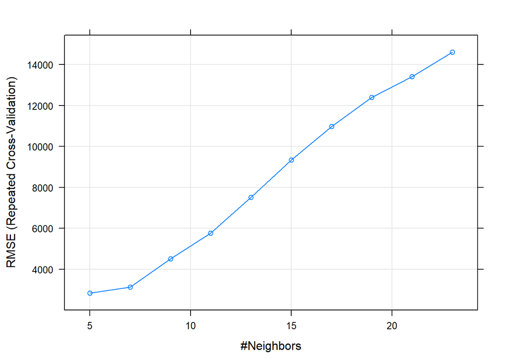

```r
plot(fit.knn)
```

```r
# k   RMSE       Rsquared   MAE
#5   2829.361  0.9906999  1618.563
```

#SVMRadial

```r
trctrl_rbf <- trainControl(method = "repeatedcv", number = 5, repeats = 3)
svmGrid <- expand.grid(sigma= 2^c(-15,-10, -5, 0), C= 2^c(0:5))
set.seed(3233)
svm_Radial <- train(Confirmed ~., data = training, method = "svmRadial",
                    trControl=trctrl_rbf,
                    preProcess = c("center", "scale"),
                    tuneGrid = svmGrid,
                    tuneLength = 10)

svm_Radial   #rbf kernel is not the method for this model
```

```
## Support Vector Machines with Radial Basis Function Kernel
##
## 68 samples
##  5 predictor
##
## Pre-processing: centered (9), scaled (9)
## Resampling: Cross-Validated (5 fold, repeated 3 times)
## Summary of sample sizes: 54, 54, 55, 56, 53, 55, ...
## Resampling results across tuning parameters:
##
##   sigma         C   RMSE      Rsquared   MAE
##   3.051758e-05   1  29730.69  0.6195862  15778.02
##   3.051758e-05   2  29730.69  0.6195862  15778.01
##   3.051758e-05   4  29730.67  0.6195862  15778.00
##   3.051758e-05   8  29730.65  0.6195862  15777.96
##   3.051758e-05  16  29730.59  0.6195862  15777.89
##   3.051758e-05  32  29730.49  0.6195862  15777.75
##   9.765625e-04   1  29730.49  0.6177295  15777.76
##   9.765625e-04   2  29730.28  0.6177295  15777.48
##   9.765625e-04   4  29729.86  0.6177295  15776.94
##   9.765625e-04   8  29729.03  0.6177295  15775.84
##   9.765625e-04  16  29727.35  0.6177295  15773.65
##   9.765625e-04  32  29724.00  0.6177295  15769.26
##   3.125000e-02   1  29726.53  0.5631456  15772.16
##   3.125000e-02   2  29722.36  0.5631456  15766.29
##   3.125000e-02   4  29714.01  0.5631725  15754.56
##   3.125000e-02   8  29696.68  0.5637539  15731.05
##   3.125000e-02  16  29660.51  0.5667360  15684.36
##   3.125000e-02  32  29573.73  0.5771893  15593.42
##   1.000000e+00   1  29727.72  0.2991133  15772.67
##   1.000000e+00   2  29724.74  0.2991133  15767.31
##   1.000000e+00   4  29718.46  0.3004599  15756.48
##   1.000000e+00   8  29705.46  0.3004599  15734.81
##   1.000000e+00  16  29675.86  0.3047799  15692.26
##   1.000000e+00  32  29601.27  0.3220652  15610.03
##
## RMSE was used to select the optimal model using the smallest value.
## The final values used for the model were sigma = 0.03125 and C = 32.
```

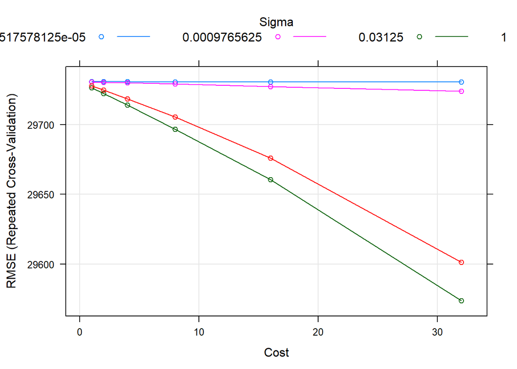

```r
plot(svm_Radial)
```

```r
test_pred <- predict(svm_Radial, newdata = testing)
test_pred
```

```
##  [1] 80378.34 80583.81 80383.27 80398.73 80401.69 80420.13 80442.91 80514.98
##  [9] 80541.45 80604.03 80728.75 80733.51 80753.63 80770.73 80879.38 81001.14
## [17] 80942.02 80941.38 81041.36 81025.33 81057.24 81083.05 81051.56 81015.34
## [25] 81142.48 81028.77
```

#Random Forest

```r
#using random search
trctrl_rf <- trainControl(method="repeatedcv", number=10, repeats=3, search="random")
set.seed(3233)
mtry <- sqrt(ncol(training))
tunegrid <- expand.grid(.mtry=mtry)
rf_gridsearch <- train(Confirmed ~ ., data = training, method="rf",
                       trControl=trctrl_rf,
                       preProcess = c("center", "scale"),
                       tuneLength = 15)
print(rf_gridsearch) #best result so far  1361.602  0.9980964    780.5278 (better than using entire China)
```

```
## Random Forest
##
## 68 samples
##  5 predictor
##
## Pre-processing: centered (9), scaled (9)
## Resampling: Cross-Validated (10 fold, repeated 3 times)
## Summary of sample sizes: 61, 62, 61, 61, 61, 61, ...
## Resampling results across tuning parameters:
##
##   mtry  RMSE       Rsquared   MAE
##   1     13658.581  0.9744536  10528.8105
##   4      1949.760  0.9966061   1061.3171
##   5      1610.192  0.9975039    891.5378
##   6      1429.860  0.9978362    817.4043
##   7      1361.602  0.9980964    780.5278
##   8      1389.254  0.9980045    790.1750
##
## RMSE was used to select the optimal model using the smallest value.
## The final value used for the model was mtry = 7.
```

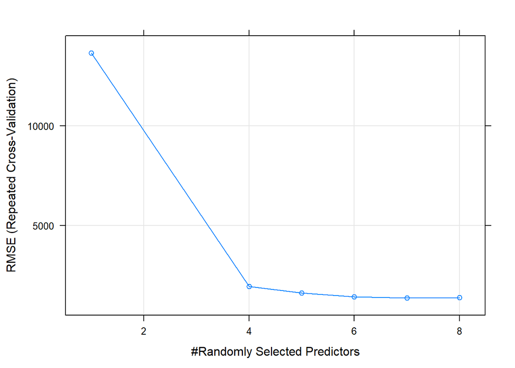

```r
plot(rf_gridsearch)
```

#standardizes test data the same way as the training data

```r
test_pred <- predict(rf_gridsearch, newdata = testing)
test_pred
```

```
##         4         6         7         8        14        18        22        28
##  2355.329  2673.485  6274.513  7745.826 21339.578 35722.823 46173.892 72340.957
##        30        35        37        45        47        49        53        57
## 75180.839 77588.424 78362.119 80594.724 80822.701 80892.091 80981.253 81118.629
##        60        62        67        71        72        82        90        91
## 81322.585 81553.669 81932.435 82257.926 82483.355 83057.294 83807.744 83843.804
##        93        96
## 83868.565 83870.032
```

#predict on entire dataset

```r
test <- predict(rf_gridsearch, newdata = China)
test
```

```
##         1         2         3         4         5         6         7         8
##  2171.435  2244.828  2267.910  2355.329  2521.312  2673.485  6274.513  7745.826
##         9        10        11        12        13        14        15        16
##  8921.510 10168.505 11122.785 15319.789 17092.074 21339.578 30530.526 31829.270
##        17        18        19        20        21        22        23        24
## 33299.772 35722.823 38774.525 39483.050 40503.228 46173.892 60839.307 66422.236
##        25        26        27        28        29        30        31        32
## 67658.302 69203.958 70100.057 72340.957 74312.963 75180.839 75390.867 76990.777
##        33        34        35        36        37        38        39        40
## 77032.402 77168.166 77588.424 78069.176 78362.119 78906.301 79256.061 79858.689
##        41        42        43        44        45        46        47        48
## 80133.419 80215.250 80322.223 80400.384 80594.724 80711.811 80822.701 80870.615
##        49        50        51        52        53        54        55        56
## 80892.091 80924.274 80929.449 80941.279 80981.253 81014.122 81041.935 81056.092
##        57        58        59        60        61        62        63        64
## 81118.629 81174.594 81243.448 81322.585 81500.916 81553.669 81628.630 81669.039
##        65        66        67        68        69        70        71        72
## 81765.210 81830.676 81932.435 82165.869 82192.660 82225.988 82257.926 82483.355
##        73        74        75        76        77        78        79        80
## 82548.083 82563.328 82617.144 82657.882 82685.565 82804.238 82891.590 82916.369
##        81        82        83        87        88        89        90        91
## 82967.590 83057.294 83181.995 83749.372 83764.142 83774.492 83807.744 83843.804
##        92        93        94        95        96        97
## 83858.263 83868.565 83872.154 83873.039 83870.032 83874.258
```

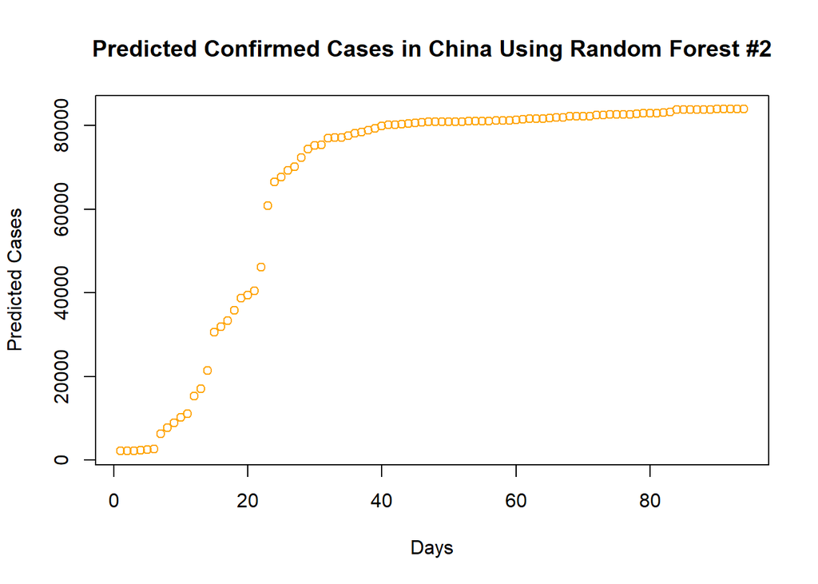

```r
plot(test, main = "Predicted Confirmed Cases in China Using Random Forest #2", xlab = "Days",
     ylab = "Predicted Cases", col = "orange")
```

#plot predicted against actual confirmed cases

```r
china_predict <- data.frame(test)
#in order to overlay the predicted plot with the actual confirmed plot, need to fix the length (3 NA rows were omitted)
temp1 <- china_predict[1:83, ]
temp2 <- china_predict[84: nrow(china_predict), ]
temp3 <- rep(NA, 3)

china_pred <- data.frame(c(temp1, temp3, temp2))

colnames(china_pred) <- "Predicted_confirmed"
china_pred$date <- date
china_pred
```

```
##    Predicted_confirmed       date
## 1             2171.435 2020-01-22
## 2             2244.828 2020-01-23
## 3             2267.910 2020-01-24
## 4             2355.329 2020-01-25
## 5             2521.312 2020-01-26
## 6             2673.485 2020-01-27
## 7             6274.513 2020-01-28
## 8             7745.826 2020-01-29
## 9             8921.510 2020-01-30
## 10           10168.505 2020-01-31
## 11           11122.785 2020-02-01
## 12           15319.789 2020-02-02
## 13           17092.074 2020-02-03
## 14           21339.578 2020-02-04
```

[output cut: 83 more lines]

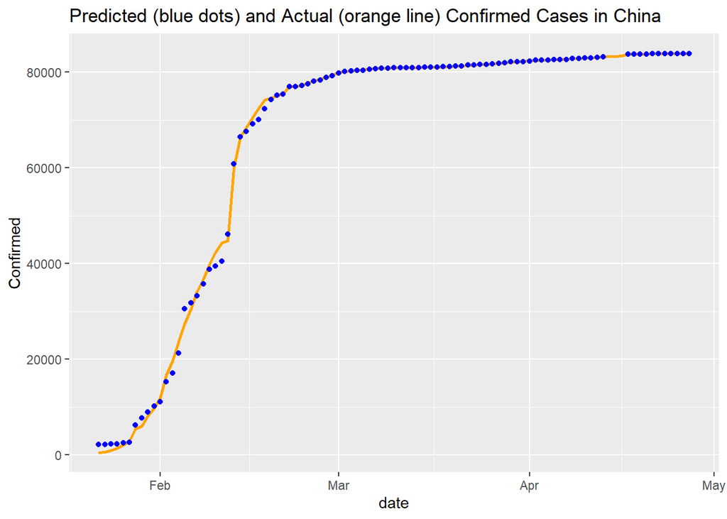

```r
f <- ggplot()+
  geom_line(data = China, mapping =aes(x = date, y = Confirmed), col = "orange", size = 1) +
  geom_point(china_pred, mapping =aes(date, Predicted_confirmed), col = "blue")+
  labs(title = "Predicted (blue dots) and Actual (orange line) Confirmed Cases in China")

plot(f)
```

3. China with confirmed converted to log to see if prediction can be further improved #china log

```r
China_log <- China
China_log <- na.omit(China_log)
China_log$Confirmed <- log(China_log$Confirmed + 1)

set.seed(3323)
intrain <- createDataPartition(y = China_log$Confirmed, p= 0.7, list = FALSE)
training <- China_log[intrain,]
testing <- China_log[-intrain,]
dim(intrain); dim(training); dim(testing)
```

```
## [1] 68  1
```

```
## [1] 68  9
```

```
## [1] 26  9
```

#rf

```r
set.seed(3233)
tc <- trainControl("oob") ##out of bag
Grid <- expand.grid(mtry = c(1:8))
fit.rf <- train(Confirmed ~., data = training , method = 'rf', trControl = tc, tuneGrid = Grid)
fit.rf  #best result: RMSE  0.24
```

```
## Random Forest
##
## 68 samples
##  8 predictor
##
## No pre-processing
## Resampling results across tuning parameters:
##
##   mtry  RMSE       Rsquared
##   1     0.6168876  0.7255442
##   2     0.3744895  0.8988561
##   3     0.3019075  0.9342633
##   4     0.2711697  0.9469675
##   5     0.2635246  0.9499156
##   6     0.2524815  0.9540252
##   7     0.2411220  0.9580691
##   8     0.2519285  0.9542264
##
## RMSE was used to select the optimal model using the smallest value.
## The final value used for the model was mtry = 7.
```

```r
test_pred <- predict(fit.rf, testing)
test_pred <- exp(test_pred)-1
test_pred
```

```
##         2        10        11        15        16        17        18        28
##  1266.183  5482.595  7080.934 22494.608 24156.672 30404.582 38670.018 71273.793
##        35        37        42        45        46        53        55        57
## 77639.651 78564.005 80238.327 80607.062 80822.235 80968.080 81062.265 81120.966
##        59        60        66        71        76        80        82        83
## 81315.747 81415.667 81857.853 82381.698 79488.815 81165.619 82964.487 81483.273
##        90        95
## 83843.181 83888.663
```

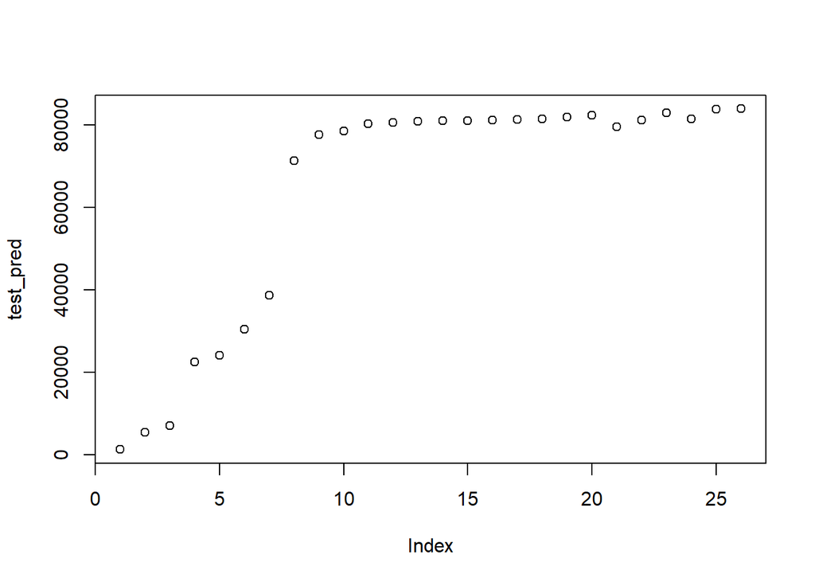

```r
plot(test_pred)
```

#predict against the whole dataset

```r
test <- predict(fit.rf, China)
test <- exp(test)-1
test
```

```
##         1         2         3         4         5         6         7         8
##  1188.194  1266.183  1261.164  1400.435  2004.918  2460.462  4713.004  4188.651
##         9        10        11        12        13        14        15        16
##  5054.959  5482.595  7080.934 19966.077 20553.826 21534.941 22494.608 24156.672
##        17        18        19        20        21        22        23        24
## 30404.582 38670.018 39613.612 40889.256 41796.413 41982.000 54606.191 64907.900
##        25        26        27        28        29        30        31        32
## 67596.294 68597.263 69891.486 71273.793 74766.554 75087.351 74949.044 75725.410
##        33        34        35        36        37        38        39        40
## 77124.555 77205.325 77639.651 78040.886 78564.005 78897.103 79156.263 79706.343
##        41        42        43        44        45        46        47        48
## 79968.477 80238.327 80312.929 80389.148 80607.062 80822.235 80842.390 80884.678
##        49        50        51        52        53        54        55        56
## 80898.968 80908.516 80930.195 80952.931 80968.080 80990.701 81062.265 81091.054
##        57        58        59        60        61        62        63        64
## 81120.966 81172.835 81315.747 81415.667 81503.410 81563.903 81599.826 81599.558
##        65        66        67        68        69        70        71        72
## 81728.209 81857.853 82060.675 82095.737 82207.335 82273.630 82381.698 82480.692
##        73        74        75        76        77        78        79        80
## 82518.001 82590.361 82597.556 79488.815 81080.647 82789.230 82822.507 81165.619
##        81        82        83        87        88        89        90        91
## 82856.422 82964.487 81483.273 83174.874 82062.112 83805.600 83843.181 83819.445
##        92        93        94        95        96        97
## 83872.132 83879.987 83835.045 83888.663 83877.848 83891.632
```